# Current Data Analysis for the Facial Expression/Cortisol Project

Julianna Calabrese

1/17/2019

```r
cp_long <- read.csv(file="C:/Users/jrcala/Documents/My Research/RStudio/cp_long.csv", header=TRUE, sep=",")
#cp_long <- read.csv(file="/Users/Julianna/Desktop/data/cp_long.csv", header=TRUE, sep=",")
cp_long$X <- NULL
```

## Introduction

This is the new version of OpenFaceAim2a.rmd, where I’m actually getting closer to doing what I’m supposed to do. The other (_old) rmd file got two big and had too many models called “mod1” and “test2” and “thing123”, so creating this file is my way of streamling things. In this file, I do my best to follow the instructions as laid out in Lopez-Duran, Mayer, & Abelson 2014. I will also try to explain everything I do in this file, why I do it, and why things may look weird at times. I will also try to name objects, variables, and models in as consistent manner as possible.

Since Lopez-Duran, Mayer, & Abelson’s 2014 paper utilized the PROC MIXED command in SAS, this RMarkdown file will use the lmer() command as part of the lme4 package. More information about lmer() can be found here: https://cran.r-project.org/web/packages/SASmixed/vignettes/Usinglmer.pdf

## Important R Information

https://swcarpentry.github.io/r-novice-inflammation/13-supp-data-structures/

Here, I wanted to explain the difference between certain data types and structures in R. It’s important because I’m trying out different kind of models with (essentially) the same variables, but the variables are different “types”. First, everything in R is an object. Before I conduct any kind of analysis or model-building, I redefine my class types to make sure that I accidentally don’t define cortisol values as a character variable.

There are six types of atomic vector types. Atomic means that the vector only holds data of asingle type.

The integer class is technically a subset of the numeric class. The main difference is about how the data are stored, not whether you have whole numbers or fractions, etc.

We can use the class() function to determine the type of an object.

```r
class(cp_long$id)
```

```
## [1] "integer"
```

## Correcting Object Class Types

### Gender

I have created multiple variables for gender in cp_long.

- gender: 0 for male, 1 for female
- gendercat: “male” for male, “female” for female
- male (integer): 1 for male, 0 for female
- malecat (character): 1 for male, 0 for female
- female: 1 for female, 0 for male
- femalecat (character): 1 for female, 0 for male

```r
cp_long$gender <- as.integer(cp_long$gender)
cp_long$gendercat <- as.character(cp_long$gendercat)
cp_long$male <- as.integer(cp_long$male)
cp_long$female <- as.integer(cp_long$female)
```

# Base models

#### Equation from Lopez-Duran 2014

$\begin{aligned} Cortisol = \beta_0 & + (\beta_1 \cdot Sex) \\ & + (\beta_2 \cdot TimeBeforePeak) \\ & + (\beta_3 \cdot TimeAfterPeak) \\ & + (\beta_4 \cdot Sex \cdot TimeBeforePeak) \\ & + (\beta_5 \cdot Sex \cdot TimeAfterPeak) \\ \end{aligned}$

#### Definitions

- b0 = intercept aka peak
- b1 = the impact of sex on levels at the group peak time
- b2 = the activation slope for males
- b3 = the regulation slope for males
- b4 = the impact of sex (females) on the activation slope
- b5 = the impact of sex (females) on the regulation slope
- timebeforepeak = the reactivity slope / activation
- timeafterpeak = the recovery slope / regulation

## Models using actual time values

The models below use variables that were made using the variables “stimeC” and “peaktimenumC”. “stime” is the actual time variable (e.g. 837, 844, 855) and “peaktimenum” is the time when the participant’s cortisol value (“cortvalue”) was highest. Therefore, for all the rows that have ID 10003, each row has a different “stime” value (e.g. 837, 844, 855, …), but each row has the same “peaktimenum” value (e.g. 844, 844, 844, …). “stimeC” is the zero-centered version of “stime” and “peaktimenumC” is the zero-centered version of “peaktimenum”.

The variable “peaknamenum” corresponds to the order in which the sample were taken. For example, for ID 10003, the time at which his cortisol peaked was 844, which was the second sample taken (out of the nine samples related to the SECPT). Therefore, for ID 10003, his “peaknamenum” is “2”.

Therefore, we want “peaknamenum” to be a character, but we want almost everything else to be numeric.

```r
cp_long$peaknamenum <- as.character(cp_long$peaknamenum)
cp_long$timetopeak <- as.numeric(cp_long$timetopeak)
cp_long$timebeforepeak <- as.numeric(cp_long$timebeforepeak)
cp_long$timeafterpeak <- as.numeric(cp_long$timeafterpeak)
cp_long$stimeC <- as.numeric(cp_long$stimeC)
cp_long$gender <- as.integer(cp_long$gender)
cp_long$female <- as.integer(cp_long$female)

cp_long$b0 <- cp_long$peaktimenumC

test1 <- lm(peaktimenumC ~ gender, data = cp_long)
summary(test1)
```

```
##
## Call:
## lm(formula = peaktimenumC ~ gender, data = cp_long)
##
## Residuals:
##     Min      1Q  Median      3Q     Max
## -2.3400 -0.6004 -0.1032  0.6430  2.3378
##
## Coefficients:
##             Estimate Std. Error t value Pr(>|t|)
## (Intercept) -0.14930    0.03627  -4.117 4.03e-05 ***
## gender       0.27079    0.04884   5.544 3.42e-08 ***
## ---
## Signif. codes:  0 '***' 0.001 '**' 0.01 '*' 0.05 '.' 0.1 ' ' 1
##
## Residual standard error: 0.9912 on 1663 degrees of freedom
## Multiple R-squared:  0.01815,    Adjusted R-squared:  0.01756
## F-statistic: 30.74 on 1 and 1663 DF,  p-value: 3.425e-08
```

```r
cp_long$b1 <- 0.27079

cp_long$b2 <- ifelse((cp_long$gender == '0'), cp_long$timebeforepeak, 0)

cp_long$b3 <- ifelse((cp_long$gender == '0'), cp_long$timeafterpeak, 0)

test2 <- lm(timebeforepeak ~ female, data=cp_long)
summary(test2)
```

```
##
## Call:
## lm(formula = timebeforepeak ~ female, data = cp_long)
##
## Residuals:
##     Min      1Q  Median      3Q     Max
## -1.1435 -0.2135  0.2373  0.2373  0.2745
##
## Coefficients:
##             Estimate Std. Error t value Pr(>|t|)
## (Intercept) -0.27446    0.01274 -21.551   <2e-16 ***
## female       0.03717    0.01715   2.167   0.0304 *
## ---
## Signif. codes:  0 '***' 0.001 '**' 0.01 '*' 0.05 '.' 0.1 ' ' 1
##
## Residual standard error: 0.3481 on 1663 degrees of freedom
## Multiple R-squared:  0.002816,   Adjusted R-squared:  0.002216
## F-statistic: 4.696 on 1 and 1663 DF,  p-value: 0.03038
```

```r
cp_long$b4 <- 0.03717

test3 <- lm(timeafterpeak ~ female, data=cp_long)
summary(test3)
```

```
##
## Call:
## lm(formula = timeafterpeak ~ female, data = cp_long)
##
## Residuals:
##     Min      1Q  Median      3Q     Max
## -0.2638 -0.2638 -0.2399  0.1877  1.4739
##
## Coefficients:
##             Estimate Std. Error t value Pr(>|t|)
## (Intercept)  0.24189    0.01384  17.483   <2e-16 ***
## female       0.02191    0.01863   1.176     0.24
## ---
## Signif. codes:  0 '***' 0.001 '**' 0.01 '*' 0.05 '.' 0.1 ' ' 1
##
## Residual standard error: 0.3781 on 1663 degrees of freedom
## Multiple R-squared:  0.0008305,  Adjusted R-squared:  0.0002297
## F-statistic: 1.382 on 1 and 1663 DF,  p-value: 0.2399
```

```r
cp_long$b5 <- 0.02191

mod1 <- lmer(cortvalue ~ (1|b0) + (1|peaktimenumC) + (b1*gender) + (b2*timebeforepeak) + (b3*timeafterpeak) + (b4*gender*timebeforepeak) + (b5*gender*timeafterpeak), data=cp_long, REML=TRUE)
```

```
## fixed-effect model matrix is rank deficient so dropping 12 columns / coefficients
```

```
## Warning in checkConv(attr(opt, "derivs"), opt$par, ctrl =
## control$checkConv, : Model failed to converge: degenerate Hessian with 1
## negative eigenvalues
```

```r
summary(mod1)
```

```
## Linear mixed model fit by REML. t-tests use Satterthwaite's method [
## lmerModLmerTest]
## Formula:
## cortvalue ~ (1 | b0) + (1 | peaktimenumC) + (b1 * gender) + (b2 *
##     timebeforepeak) + (b3 * timeafterpeak) + (b4 * gender * timebeforepeak) +
##     (b5 * gender * timeafterpeak)
##    Data: cp_long
##
## REML criterion at convergence: 4343.6
##
## Scaled residuals:
##     Min      1Q  Median      3Q     Max
## -2.5667 -0.6009 -0.0323  0.5166  8.2718
##
## Random effects:
##  Groups       Name        Variance Std.Dev.
##  b0           (Intercept) 0.05884  0.2426
##  peaktimenumC (Intercept) 0.32212  0.5676
##  Residual                 0.64695  0.8043
## Number of obs: 1665, groups:  b0, 200; peaktimenumC, 200
##
## Fixed effects:
##                     Estimate Std. Error         df t value Pr(>|t|)
## (Intercept)          3.70283    0.09032 1088.42659  40.995  < 2e-16 ***
## gender              -0.36017    0.09674 1641.54838  -3.723 0.000204 ***
## b2                   0.76374    0.35003 1532.99381   2.182 0.029267 *
## timebeforepeak       0.89344    0.10942 1652.57159   8.166 6.28e-16 ***
## b3                  -0.19475    0.33656 1588.81990  -0.579 0.562894
## timeafterpeak       -0.88072    0.10204 1572.63128  -8.632  < 2e-16 ***
## b2:timebeforepeak    0.83119    0.28863 1504.52229   2.880 0.004036 **
## b3:timeafterpeak     0.18944    0.24856 1594.84559   0.762 0.446100
## ---
## Signif. codes:  0 '***' 0.001 '**' 0.01 '*' 0.05 '.' 0.1 ' ' 1
##
## Correlation of Fixed Effects:
##             (Intr) gender b2     tmbfrp b3     tmftrp b2:tmb
## gender      -0.722
## b2           0.586 -0.661
## timebeforpk  0.015  0.335 -0.263
## b3          -0.556  0.636 -0.477  0.122
## timeafterpk -0.028 -0.367  0.142 -0.351 -0.299
## b2:timbfrpk  0.465 -0.439  0.898  0.028 -0.351  0.021
## b3:timftrpk  0.419 -0.402  0.336 -0.012 -0.893  0.026  0.268
## fit warnings:
## fixed-effect model matrix is rank deficient so dropping 12 columns / coefficients
## convergence code: 0
## unable to evaluate scaled gradient
## Model failed to converge: degenerate  Hessian with 1 negative eigenvalues
```

```r
rm(test1)
rm(test2)
rm(test3)

cp_long$b0 <- NULL
cp_long$b1 <- NULL
cp_long$b2 <- NULL
cp_long$b3 <- NULL
cp_long$b4 <- NULL
cp_long$b5 <- NULL
```

The model “mod1” showcased the following warnings:

> fixed-effect model matrix is rank deficient so dropping 12 columns/coefficient

> Warning messages

> 1: In checkConv(attr(opt, “derivs”), opt$par, ctrl = control$checkConv, : unable to evaluate scaled gradient

> 2: In checkConv(attr(opt, “derivs”), opt$par, ctrl = control$checkConv, : Model failed to converge: degenerate Hessian with 1 negative eigenvalues

```r
cp_long$peaknamenum <- as.character(cp_long$peaknamenum)
cp_long$timetopeak <- as.numeric(cp_long$timetopeak)
cp_long$timebeforepeak <- as.numeric(cp_long$timebeforepeak)
cp_long$timeafterpeak <- as.numeric(cp_long$timeafterpeak)
cp_long$stimeC <- as.numeric(cp_long$stimeC)
cp_long$gender <- as.integer(cp_long$gender)
cp_long$female <- as.integer(cp_long$female)

cp_long$b0 <- cp_long$peaknamenum

test1 <- lm(peaknamenum ~ gender, data = cp_long)
summary(test1)
```

```
##
## Call:
## lm(formula = peaknamenum ~ gender, data = cp_long)
##
## Residuals:
##    Min     1Q Median     3Q    Max
## -5.277 -2.277  1.127  2.127  3.127
##
## Coefficients:
##             Estimate Std. Error t value Pr(>|t|)
## (Intercept)   6.2771     0.1010  62.151  < 2e-16 ***
## gender       -0.4046     0.1360  -2.974  0.00298 **
## ---
## Signif. codes:  0 '***' 0.001 '**' 0.01 '*' 0.05 '.' 0.1 ' ' 1
##
## Residual standard error: 2.76 on 1663 degrees of freedom
## Multiple R-squared:  0.005291,   Adjusted R-squared:  0.004693
## F-statistic: 8.846 on 1 and 1663 DF,  p-value: 0.002979
```

```r
cp_long$b1 <- -0.4046

cp_long$b2 <- ifelse((cp_long$gender == '0'), cp_long$timebeforepeak, 0)

cp_long$b3 <- ifelse((cp_long$gender == '0'), cp_long$timeafterpeak, 0)

test2 <- lm(timebeforepeak ~ female, data=cp_long)
summary(test2)
```

```
##
## Call:
## lm(formula = timebeforepeak ~ female, data = cp_long)
##
## Residuals:
##     Min      1Q  Median      3Q     Max
## -1.1435 -0.2135  0.2373  0.2373  0.2745
##
## Coefficients:
##             Estimate Std. Error t value Pr(>|t|)
## (Intercept) -0.27446    0.01274 -21.551   <2e-16 ***
## female       0.03717    0.01715   2.167   0.0304 *
## ---
## Signif. codes:  0 '***' 0.001 '**' 0.01 '*' 0.05 '.' 0.1 ' ' 1
##
## Residual standard error: 0.3481 on 1663 degrees of freedom
## Multiple R-squared:  0.002816,   Adjusted R-squared:  0.002216
## F-statistic: 4.696 on 1 and 1663 DF,  p-value: 0.03038
```

```r
cp_long$b4 <- 0.03717

test3 <- lm(timeafterpeak ~ female, data=cp_long)
summary(test3)
```

```
##
## Call:
## lm(formula = timeafterpeak ~ female, data = cp_long)
##
## Residuals:
##     Min      1Q  Median      3Q     Max
## -0.2638 -0.2638 -0.2399  0.1877  1.4739
##
## Coefficients:
##             Estimate Std. Error t value Pr(>|t|)
## (Intercept)  0.24189    0.01384  17.483   <2e-16 ***
## female       0.02191    0.01863   1.176     0.24
## ---
## Signif. codes:  0 '***' 0.001 '**' 0.01 '*' 0.05 '.' 0.1 ' ' 1
##
## Residual standard error: 0.3781 on 1663 degrees of freedom
## Multiple R-squared:  0.0008305,  Adjusted R-squared:  0.0002297
## F-statistic: 1.382 on 1 and 1663 DF,  p-value: 0.2399
```

```r
cp_long$b5 <- 0.02191

mod2 <- lmer(cortvalue ~ (1|b0) + (1|peaknamenum) + (b1*gender) + (b2*timebeforepeak) + (b3*timeafterpeak) + (b4*gender*timebeforepeak) + (b5*gender*timeafterpeak), data=cp_long, REML=TRUE)
```

```
## fixed-effect model matrix is rank deficient so dropping 12 columns / coefficients
```

```
## Warning: Model failed to converge with 1 negative eigenvalue: -3.4e-05
```

```r
summary(mod2)
```

```
## Linear mixed model fit by REML. t-tests use Satterthwaite's method [
## lmerModLmerTest]
## Formula: cortvalue ~ (1 | b0) + (1 | peaknamenum) + (b1 * gender) + (b2 *
##     timebeforepeak) + (b3 * timeafterpeak) + (b4 * gender * timebeforepeak) +
##     (b5 * gender * timeafterpeak)
##    Data: cp_long
##
## REML criterion at convergence: 4519.5
##
## Scaled residuals:
##     Min      1Q  Median      3Q     Max
## -2.5021 -0.7130 -0.0225  0.5909  7.1358
##
## Random effects:
##  Groups      Name        Variance Std.Dev.
##  b0          (Intercept) 0.06405  0.2531
##  peaknamenum (Intercept) 0.13544  0.3680
##  Residual                0.86153  0.9282
## Number of obs: 1665, groups:  b0, 9; peaknamenum, 9
##
## Fixed effects:
##                     Estimate Std. Error         df t value Pr(>|t|)
## (Intercept)          3.66642    0.17258   13.17689  21.245 1.40e-11 ***
## gender              -0.43179    0.09886 1650.87916  -4.368 1.33e-05 ***
## b2                   1.06776    0.38351 1649.18243   2.784  0.00543 **
## timebeforepeak       0.97976    0.11061 1655.82890   8.858  < 2e-16 ***
## b3                  -0.31751    0.36000 1650.47694  -0.882  0.37791
## timeafterpeak       -0.42961    0.10876 1631.63534  -3.950 8.14e-05 ***
## b2:timebeforepeak    1.05365    0.32098 1649.09168   3.283  0.00105 **
## b3:timeafterpeak     0.33539    0.26470 1650.39459   1.267  0.20531
## ---
## Signif. codes:  0 '***' 0.001 '**' 0.01 '*' 0.05 '.' 0.1 ' ' 1
##
## Correlation of Fixed Effects:
##             (Intr) gender b2     tmbfrp b3     tmftrp b2:tmb
## gender      -0.414
## b2           0.347 -0.711
## timebeforpk -0.030  0.387 -0.269
## b3          -0.355  0.704 -0.551  0.150
## timeafterpk -0.065 -0.305  0.122 -0.344 -0.200
## b2:timbfrpk  0.276 -0.489  0.912 -0.007 -0.415  0.015
## b3:timftrpk  0.293 -0.497  0.421 -0.028 -0.914 -0.022  0.338
## fit warnings:
## fixed-effect model matrix is rank deficient so dropping 12 columns / coefficients
```

```r
rm(test1)
rm(test2)
rm(test3)

cp_long$b0 <- NULL
cp_long$b1 <- NULL
cp_long$b2 <- NULL
cp_long$b3 <- NULL
cp_long$b4 <- NULL
cp_long$b5 <- NULL
```

The model “mod2” showcased the following warnings:

> fixed-effect model matrix is rank deficient so dropping 12 columns/coefficients

> Warning message:

> Model failed to converge with 1 negative eigenvalue: -3.4e-05

## Models using “sample” time values

In cp_long, “samplepeaknamenum” is the variable that corresponds to the nine samples and the amount of minutes after the cold press task: 0, 3, 15, 25, 30, 35, 40, 45, 60.

Like shown above, alternatives include “stime” or “stimeC” (which is stime but zero-centered), which is the actual amount of minutes between each sample (e.g. 837, 844, 855, …) or timenum, which is the mostly just the sample number. timenum is 4, 5, 6, 7, 8, 9, 10, 11, and 12, while timenum is “centered” (not really though–it just assumes that the fourth sample is actually the first sample, since we don’t care about cortisol levels during the MRI) and is 1, 2, 3, 4, 5, 6, 7, 8, and 9.

Therefore, any variable that begins with “sample” is based off this 0, 3, 15, etc. sequence: samplepeaknamenum, sampletimetopeak, sampletimebeforepeak, and sampletimeafterpeak. The reason I went with the “sample” version of the time variable is because we would be able to treat time as a factor instead of as an integer or as a numeric variable.

As opposed to the first and second models, I believe that the third model is the closest to the models in Lopez-Duran 2014 as possible.

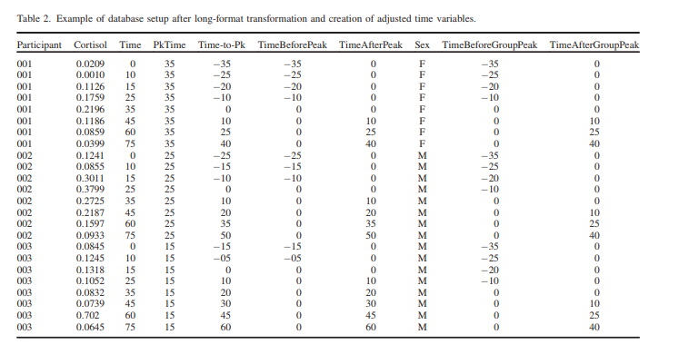

According to Table 2 in Lopez-Duran 2014, there were no “actual time” values (i.e. 837, 844, 855, …), just the “minute” values (i.e. 0, 3, 15, …).

Additionally, in his table, gender is M/F. So I transformed “gender” and “female” from integers to character variables, which makes them identical to a M/F system.

Before we start the below model, I want to make sure of the data types.

```r
cp_long$samplepeaknamenum <- as.integer(cp_long$samplepeaknamenum)
cp_long$sampletimetopeak <- as.integer(cp_long$sampletimetopeak)
cp_long$sampletimebeforepeak <- as.integer(cp_long$sampletimebeforepeak)
cp_long$sampletimeafterpeak <- as.integer(cp_long$sampletimeafterpeak)
cp_long$gender <- as.character(cp_long$gender)
cp_long$female <- as.character(cp_long$female)

cp_long$b0 <- cp_long$samplepeaknamenum

test1 <- lm(samplepeaknamenum ~ gender, data = cp_long)
summary(test1)
```

```
##
## Call:
## lm(formula = samplepeaknamenum ~ gender, data = cp_long)
##
## Residuals:
##     Min      1Q  Median      3Q     Max
## -36.542 -11.542   6.157  11.157  26.157
##
## Coefficients:
##             Estimate Std. Error t value Pr(>|t|)
## (Intercept)  36.5422     0.7398  49.394  < 2e-16 ***
## gender1      -2.6990     0.9963  -2.709  0.00682 **
## ---
## Signif. codes:  0 '***' 0.001 '**' 0.01 '*' 0.05 '.' 0.1 ' ' 1
##
## Residual standard error: 20.22 on 1663 degrees of freedom
## Multiple R-squared:  0.004393,   Adjusted R-squared:  0.003795
## F-statistic: 7.338 on 1 and 1663 DF,  p-value: 0.006819
```

```r
cp_long$b1 <- -2.6990

cp_long$b2 <- ifelse((cp_long$gender == "0"), cp_long$sampletimebeforepeak, 0)

cp_long$b3 <- ifelse((cp_long$gender == "0"), cp_long$sampletimeafterpeak, 0)

test2 <- lm(sampletimebeforepeak ~ female, data=cp_long)
summary(test2)
```

```
##
## Call:
## lm(formula = sampletimebeforepeak ~ female, data = cp_long)
##
## Residuals:
##    Min     1Q Median     3Q    Max
## -45.99 -11.01   9.01  14.01  15.99
##
## Coefficients:
##             Estimate Std. Error t value Pr(>|t|)
## (Intercept) -15.9906     0.6471 -24.710   <2e-16 ***
## female1       1.9808     0.8715   2.273   0.0232 *
## ---
## Signif. codes:  0 '***' 0.001 '**' 0.01 '*' 0.05 '.' 0.1 ' ' 1
##
## Residual standard error: 17.69 on 1663 degrees of freedom
## Multiple R-squared:  0.003097,   Adjusted R-squared:  0.002497
## F-statistic: 5.166 on 1 and 1663 DF,  p-value: 0.02316
```

```r
cp_long$b4 <-  1.9808

test3 <- lm(sampletimeafterpeak ~ female, data=cp_long)
summary(test3)
```

```
##
## Call:
## lm(formula = sampletimeafterpeak ~ female, data = cp_long)
##
## Residuals:
##    Min     1Q Median     3Q    Max
## -8.278 -8.278 -7.560  4.440 52.440
##
## Coefficients:
##             Estimate Std. Error t value Pr(>|t|)
## (Intercept)   7.5596     0.5225  14.469   <2e-16 ***
## female1       0.7182     0.7036   1.021    0.308
## ---
## Signif. codes:  0 '***' 0.001 '**' 0.01 '*' 0.05 '.' 0.1 ' ' 1
##
## Residual standard error: 14.28 on 1663 degrees of freedom
## Multiple R-squared:  0.0006261,  Adjusted R-squared:  2.517e-05
## F-statistic: 1.042 on 1 and 1663 DF,  p-value: 0.3075
```

```r
cp_long$b5 <- 0.7182

mod3 <- lmer(cortvalue ~ (1|b0) + (1|samplepeaknamenum) + (b1*gender) + (b2*sampletimebeforepeak) + (b3*sampletimeafterpeak) + (b4*gender*sampletimebeforepeak) + (b5*gender*sampletimeafterpeak), data=cp_long, REML=TRUE)
```

```
## fixed-effect model matrix is rank deficient so dropping 12 columns / coefficients
```

```r
summary(mod3)
```

```
## Linear mixed model fit by REML. t-tests use Satterthwaite's method [
## lmerModLmerTest]
## Formula: cortvalue ~ (1 | b0) + (1 | samplepeaknamenum) + (b1 * gender) +
##     (b2 * sampletimebeforepeak) + (b3 * sampletimeafterpeak) +
##     (b4 * gender * sampletimebeforepeak) + (b5 * gender * sampletimeafterpeak)
##    Data: cp_long
##
## REML criterion at convergence: 4524.7
##
## Scaled residuals:
##     Min      1Q  Median      3Q     Max
## -2.5227 -0.7154 -0.0256  0.6220  7.1042
##
## Random effects:
##  Groups            Name        Variance Std.Dev.
##  b0                (Intercept) 0.06184  0.2487
##  samplepeaknamenum (Intercept) 0.13197  0.3633
##  Residual                      0.83318  0.9128
## Number of obs: 1665, groups:  b0, 9; samplepeaknamenum, 9
##
## Fixed effects:
##                           Estimate Std. Error         df t value Pr(>|t|)
## (Intercept)              3.810e+00  1.655e-01  1.184e+01  23.019 3.39e-11
## gender1                 -4.869e-01  9.102e-02  1.651e+03  -5.349 1.01e-07
## b2                       2.285e-02  7.081e-03  1.650e+03   3.226 0.001279
## sampletimebeforepeak     2.185e-02  2.141e-03  1.657e+03  10.206  < 2e-16
## b3                      -2.495e-02  8.623e-03  1.650e+03  -2.893 0.003863
## sampletimeafterpeak     -1.592e-02  2.717e-03  1.642e+03  -5.860 5.57e-09
## b2:sampletimebeforepeak  4.355e-04  1.229e-04  1.650e+03   3.542 0.000408
## b3:sampletimeafterpeak   6.137e-04  1.673e-04  1.650e+03   3.668 0.000252
##
## (Intercept)             ***
## gender1                 ***
## b2                      **
## sampletimebeforepeak    ***
## b3                      **
## sampletimeafterpeak     ***
## b2:sampletimebeforepeak ***
## b3:sampletimeafterpeak  ***
## ---
## Signif. codes:  0 '***' 0.001 '**' 0.01 '*' 0.05 '.' 0.1 ' ' 1
##
## Correlation of Fixed Effects:
##             (Intr) gendr1 b2     smpltmb b3     smpltmf b2:smp
## gender1     -0.374
## b2           0.314 -0.699
## smpltmbfrpk -0.026  0.410 -0.263
## b3          -0.277  0.597 -0.460  0.153
## smpltmftrpk -0.029 -0.326  0.153 -0.300  -0.234
## b2:smpltmbf  0.246 -0.464  0.909  0.000  -0.335  0.045
## b3:smpltmft  0.206 -0.367  0.310 -0.032  -0.901 -0.012   0.245
## fit warnings:
## fixed-effect model matrix is rank deficient so dropping 12 columns / coefficients
```

```r
rm(test1)
rm(test2)
rm(test3)

cp_long$b0 <- NULL
cp_long$b1 <- NULL
cp_long$b2 <- NULL
cp_long$b3 <- NULL
cp_long$b4 <- NULL
cp_long$b5 <- NULL
```

The model “mod3” showcased the following warnings:

> fixed-effect model matrix is rank deficient so dropping 12 columns/coefficients

This may be a sign that the third model is best, because it showcased no “fail to converge” warnings like the first and second model.

## Base model findings and conclusions

Note: don’t try to summary() any of the models because I removed neccessary components of the models to reduce confusion in the environment.

https://stackoverflow.com/questions/38766155/rank-deficiency-warning-mixed-model-lmer

In the above, Ben Bolker (the creator of the package lme4) explains the warning. Generally, as far as I can read, this warning is not an issue. If I created a similiar model using lm(), I would have the same “problem” but the command wouldn’t give me a warning because it hasn’t been designed to give me a warning. It’s just that lmer() gives me the courtesy of a warning while other commands often don’t.

Below is also a helpful link about this issue.

https://stackoverflow.com/questions/37090722/lme4lmer-reports-fixed-effect-model-matrix-is-rank-deficient-do-i-need-a-fi

Second, I will discuss the model failing to converge.

https://stats.stackexchange.com/questions/242109/model-failed-to-converge-warning-in-lmer

I am still not 100% what this warning means from a statistical standpoint, but the StackExchange answer does give me a solution that prevents me from getting these scary warnings. First, REML has to remain *TRUE* no matter what since that is specified in Lopez-Duran 2014. Additionally, I have to add the following syntax to my models:

> control = lmerControl(optimizer =‘optimx’, optCtrl=list(method=‘L-BFGS-B’)))

This syntax “optimizes” the model by using the L-BFGS-B routine as part of the optimx package. I still need to learn more about this. So, I will duplicate the above three models, but this time I will add the new syntax at the end.

## Base models with optimization

```r
cp_long$peaknamenum <- as.character(cp_long$peaknamenum)
cp_long$timetopeak <- as.numeric(cp_long$timetopeak)
cp_long$timebeforepeak <- as.numeric(cp_long$timebeforepeak)
cp_long$timeafterpeak <- as.numeric(cp_long$timeafterpeak)
cp_long$stimeC <- as.numeric(cp_long$stimeC)
cp_long$gender <- as.integer(cp_long$gender)
cp_long$female <- as.integer(cp_long$female)
```

```r
cp_long$b0 <- cp_long$peaktimenumC

test1 <- lm(peaktimenumC ~ gender, data = cp_long)
summary(test1)
```

```
##
## Call:
## lm(formula = peaktimenumC ~ gender, data = cp_long)
##
## Residuals:
##     Min      1Q  Median      3Q     Max
## -2.3400 -0.6004 -0.1032  0.6430  2.3378
##
## Coefficients:
##             Estimate Std. Error t value Pr(>|t|)
## (Intercept) -0.14930    0.03627  -4.117 4.03e-05 ***
## gender       0.27079    0.04884   5.544 3.42e-08 ***
## ---
## Signif. codes:  0 '***' 0.001 '**' 0.01 '*' 0.05 '.' 0.1 ' ' 1
##
## Residual standard error: 0.9912 on 1663 degrees of freedom
## Multiple R-squared:  0.01815,    Adjusted R-squared:  0.01756
## F-statistic: 30.74 on 1 and 1663 DF,  p-value: 3.425e-08
```

```r
cp_long$b1 <- 0.27079

cp_long$b2 <- ifelse((cp_long$gender == '0'), cp_long$timebeforepeak, 0)

cp_long$b3 <- ifelse((cp_long$gender == '0'), cp_long$timeafterpeak, 0)

test2 <- lm(timebeforepeak ~ female, data=cp_long)
summary(test2)
```

```
##
## Call:
## lm(formula = timebeforepeak ~ female, data = cp_long)
##
## Residuals:
##     Min      1Q  Median      3Q     Max
## -1.1435 -0.2135  0.2373  0.2373  0.2745
##
## Coefficients:
##             Estimate Std. Error t value Pr(>|t|)
## (Intercept) -0.27446    0.01274 -21.551   <2e-16 ***
## female       0.03717    0.01715   2.167   0.0304 *
## ---
## Signif. codes:  0 '***' 0.001 '**' 0.01 '*' 0.05 '.' 0.1 ' ' 1
##
## Residual standard error: 0.3481 on 1663 degrees of freedom
## Multiple R-squared:  0.002816,   Adjusted R-squared:  0.002216
## F-statistic: 4.696 on 1 and 1663 DF,  p-value: 0.03038
```

```r
cp_long$b4 <- 0.03717

test3 <- lm(timeafterpeak ~ female, data=cp_long)
summary(test3)
```

```
##
## Call:
## lm(formula = timeafterpeak ~ female, data = cp_long)
##
## Residuals:
##     Min      1Q  Median      3Q     Max
## -0.2638 -0.2638 -0.2399  0.1877  1.4739
##
## Coefficients:
##             Estimate Std. Error t value Pr(>|t|)
## (Intercept)  0.24189    0.01384  17.483   <2e-16 ***
## female       0.02191    0.01863   1.176     0.24
## ---
## Signif. codes:  0 '***' 0.001 '**' 0.01 '*' 0.05 '.' 0.1 ' ' 1
##
## Residual standard error: 0.3781 on 1663 degrees of freedom
## Multiple R-squared:  0.0008305,  Adjusted R-squared:  0.0002297
## F-statistic: 1.382 on 1 and 1663 DF,  p-value: 0.2399
```

```r
cp_long$b5 <- 0.02191

modopt1 <- lmer(cortvalue ~ (1|b0) + (1|peaktimenumC) + (b1*gender) + (b2*timebeforepeak) + (b3*timeafterpeak) + (b4*gender*timebeforepeak) + (b5*gender*timeafterpeak), data=cp_long, REML=TRUE, control = lmerControl(optimizer ='optimx', optCtrl=list(method='L-BFGS-B')))
```

```
## fixed-effect model matrix is rank deficient so dropping 12 columns / coefficients
## fixed-effect model matrix is rank deficient so dropping 12 columns / coefficients
```

```
## Warning: Model failed to converge with 1 negative eigenvalue: -1.6e-05
```

```r
summary(modopt1)
```

```
## Linear mixed model fit by REML. t-tests use Satterthwaite's method [
## lmerModLmerTest]
## Formula:
## cortvalue ~ (1 | b0) + (1 | peaktimenumC) + (b1 * gender) + (b2 *
##     timebeforepeak) + (b3 * timeafterpeak) + (b4 * gender * timebeforepeak) +
##     (b5 * gender * timeafterpeak)
##    Data: cp_long
## Control:
## lmerControl(optimizer = "optimx", optCtrl = list(method = "L-BFGS-B"))
##
## REML criterion at convergence: 4343.6
##
## Scaled residuals:
##     Min      1Q  Median      3Q     Max
## -2.5667 -0.6009 -0.0323  0.5166  8.2718
##
## Random effects:
##  Groups       Name        Variance Std.Dev.
##  b0           (Intercept) 0.1905   0.4364
##  peaktimenumC (Intercept) 0.1905   0.4364
##  Residual                 0.6469   0.8043
## Number of obs: 1665, groups:  b0, 200; peaktimenumC, 200
##
## Fixed effects:
##                     Estimate Std. Error         df t value Pr(>|t|)
## (Intercept)          3.70283    0.09032 1088.42673  40.995  < 2e-16 ***
## gender              -0.36017    0.09674 1641.54838  -3.723 0.000204 ***
## b2                   0.76374    0.35003 1532.99380   2.182 0.029267 *
## timebeforepeak       0.89344    0.10942 1652.57159   8.166 6.28e-16 ***
## b3                  -0.19475    0.33656 1588.81989  -0.579 0.562894
## timeafterpeak       -0.88072    0.10204 1572.63129  -8.632  < 2e-16 ***
## b2:timebeforepeak    0.83119    0.28863 1504.52228   2.880 0.004036 **
## b3:timeafterpeak     0.18944    0.24856 1594.84558   0.762 0.446100
## ---
## Signif. codes:  0 '***' 0.001 '**' 0.01 '*' 0.05 '.' 0.1 ' ' 1
##
## Correlation of Fixed Effects:
##             (Intr) gender b2     tmbfrp b3     tmftrp b2:tmb
## gender      -0.722
## b2           0.586 -0.661
## timebeforpk  0.015  0.335 -0.263
## b3          -0.556  0.636 -0.477  0.122
## timeafterpk -0.028 -0.367  0.142 -0.351 -0.299
## b2:timbfrpk  0.465 -0.439  0.898  0.028 -0.351  0.021
## b3:timftrpk  0.419 -0.402  0.336 -0.012 -0.893  0.026  0.268
## fit warnings:
## fixed-effect model matrix is rank deficient so dropping 12 columns / coefficients
```

```r
rm(test1)
rm(test2)
rm(test3)

cp_long$b0 <- NULL
cp_long$b1 <- NULL
cp_long$b2 <- NULL
cp_long$b3 <- NULL
cp_long$b4 <- NULL
cp_long$b5 <- NULL
```

The model “modopt1” showcased the following warnings:

> fixed-effect model matrix is rank deficient so dropping 12 columns/coefficients

> fixed-effect model matrix is rank deficient so dropping 12 columns/coefficients

> Warning message:

> Model failed to converge with 1 negative eigenvalue: -1.6e-05

So unfortunately for “mod1” and “modopt1”, optimization doesn’t seem to remove the warning. Let’s try for “mod2”. I am not also 100% sure why it showcases the “dropping 12 columns” warning twice, but I don’t think the warning itself is something to be very worried about.

```r
cp_long$peaknamenum <- as.character(cp_long$peaknamenum)
cp_long$timetopeak <- as.numeric(cp_long$timetopeak)
cp_long$timebeforepeak <- as.numeric(cp_long$timebeforepeak)
cp_long$timeafterpeak <- as.numeric(cp_long$timeafterpeak)
cp_long$stimeC <- as.numeric(cp_long$stimeC)
cp_long$gender <- as.integer(cp_long$gender)
cp_long$female <- as.integer(cp_long$female)

cp_long$b0 <- cp_long$peaknamenum

test1 <- lm(peaknamenum ~ gender, data = cp_long)
summary(test1)
```

```
##
## Call:
## lm(formula = peaknamenum ~ gender, data = cp_long)
##
## Residuals:
##    Min     1Q Median     3Q    Max
## -5.277 -2.277  1.127  2.127  3.127
##
## Coefficients:
##             Estimate Std. Error t value Pr(>|t|)
## (Intercept)   6.2771     0.1010  62.151  < 2e-16 ***
## gender       -0.4046     0.1360  -2.974  0.00298 **
## ---
## Signif. codes:  0 '***' 0.001 '**' 0.01 '*' 0.05 '.' 0.1 ' ' 1
##
## Residual standard error: 2.76 on 1663 degrees of freedom
## Multiple R-squared:  0.005291,   Adjusted R-squared:  0.004693
## F-statistic: 8.846 on 1 and 1663 DF,  p-value: 0.002979
```

```r
cp_long$b1 <- -0.4046

cp_long$b2 <- ifelse((cp_long$gender == '0'), cp_long$timebeforepeak, 0)

cp_long$b3 <- ifelse((cp_long$gender == '0'), cp_long$timeafterpeak, 0)

test2 <- lm(timebeforepeak ~ female, data=cp_long)
summary(test2)
```

```
##
## Call:
## lm(formula = timebeforepeak ~ female, data = cp_long)
##
## Residuals:
##     Min      1Q  Median      3Q     Max
## -1.1435 -0.2135  0.2373  0.2373  0.2745
##
## Coefficients:
##             Estimate Std. Error t value Pr(>|t|)
## (Intercept) -0.27446    0.01274 -21.551   <2e-16 ***
## female       0.03717    0.01715   2.167   0.0304 *
## ---
## Signif. codes:  0 '***' 0.001 '**' 0.01 '*' 0.05 '.' 0.1 ' ' 1
##
## Residual standard error: 0.3481 on 1663 degrees of freedom
## Multiple R-squared:  0.002816,   Adjusted R-squared:  0.002216
## F-statistic: 4.696 on 1 and 1663 DF,  p-value: 0.03038
```

```r
cp_long$b4 <- 0.03717

test3 <- lm(timeafterpeak ~ female, data=cp_long)
summary(test3)
```

```
##
## Call:
## lm(formula = timeafterpeak ~ female, data = cp_long)
##
## Residuals:
##     Min      1Q  Median      3Q     Max
## -0.2638 -0.2638 -0.2399  0.1877  1.4739
##
## Coefficients:
##             Estimate Std. Error t value Pr(>|t|)
## (Intercept)  0.24189    0.01384  17.483   <2e-16 ***
## female       0.02191    0.01863   1.176     0.24
## ---
## Signif. codes:  0 '***' 0.001 '**' 0.01 '*' 0.05 '.' 0.1 ' ' 1
##
## Residual standard error: 0.3781 on 1663 degrees of freedom
## Multiple R-squared:  0.0008305,  Adjusted R-squared:  0.0002297
## F-statistic: 1.382 on 1 and 1663 DF,  p-value: 0.2399
```

```r
cp_long$b5 <- 0.02191

modopt2 <- lmer(cortvalue ~ (1|b0) + (1|peaknamenum) + (b1*gender) + (b2*timebeforepeak) + (b3*timeafterpeak) + (b4*gender*timebeforepeak) + (b5*gender*timeafterpeak), data=cp_long, REML=TRUE, control = lmerControl(optimizer ='optimx', optCtrl=list(method='L-BFGS-B')))
```

```
## fixed-effect model matrix is rank deficient so dropping 12 columns / coefficients
## fixed-effect model matrix is rank deficient so dropping 12 columns / coefficients
```

```r
summary(modopt2)
```

```
## Linear mixed model fit by REML. t-tests use Satterthwaite's method [
## lmerModLmerTest]
## Formula: cortvalue ~ (1 | b0) + (1 | peaknamenum) + (b1 * gender) + (b2 *
##     timebeforepeak) + (b3 * timeafterpeak) + (b4 * gender * timebeforepeak) +
##     (b5 * gender * timeafterpeak)
##    Data: cp_long
## Control:
## lmerControl(optimizer = "optimx", optCtrl = list(method = "L-BFGS-B"))
##
## REML criterion at convergence: 4519.5
##
## Scaled residuals:
##     Min      1Q  Median      3Q     Max
## -2.5021 -0.7130 -0.0225  0.5909  7.1358
##
## Random effects:
##  Groups      Name        Variance Std.Dev.
##  b0          (Intercept) 0.09975  0.3158
##  peaknamenum (Intercept) 0.09975  0.3158
##  Residual                0.86153  0.9282
## Number of obs: 1665, groups:  b0, 9; peaknamenum, 9
##
## Fixed effects:
##                     Estimate Std. Error         df t value Pr(>|t|)
## (Intercept)          3.66642    0.17258   13.17671  21.245 1.40e-11 ***
## gender              -0.43179    0.09886 1650.87918  -4.368 1.33e-05 ***
## b2                   1.06776    0.38351 1649.18246   2.784  0.00543 **
## timebeforepeak       0.97976    0.11061 1655.82890   8.858  < 2e-16 ***
## b3                  -0.31751    0.36000 1650.47696  -0.882  0.37791
## timeafterpeak       -0.42961    0.10876 1631.63544  -3.950 8.14e-05 ***
## b2:timebeforepeak    1.05365    0.32098 1649.09172   3.283  0.00105 **
## b3:timeafterpeak     0.33539    0.26470 1650.39462   1.267  0.20531
## ---
## Signif. codes:  0 '***' 0.001 '**' 0.01 '*' 0.05 '.' 0.1 ' ' 1
##
## Correlation of Fixed Effects:
##             (Intr) gender b2     tmbfrp b3     tmftrp b2:tmb
## gender      -0.414
## b2           0.347 -0.711
## timebeforpk -0.030  0.387 -0.269
## b3          -0.355  0.704 -0.551  0.150
## timeafterpk -0.065 -0.305  0.122 -0.344 -0.200
## b2:timbfrpk  0.276 -0.489  0.912 -0.007 -0.415  0.015
## b3:timftrpk  0.293 -0.497  0.421 -0.028 -0.914 -0.022  0.338
## fit warnings:
## fixed-effect model matrix is rank deficient so dropping 12 columns / coefficients
```

```r
rm(test1)
rm(test2)
rm(test3)

cp_long$b0 <- NULL
cp_long$b1 <- NULL
cp_long$b2 <- NULL
cp_long$b3 <- NULL
cp_long$b4 <- NULL
cp_long$b5 <- NULL
```

The model “modopt2” showcased the following warnings:

> fixed-effect model matrix is rank deficient so dropping 12 columns / coefficient

> fixed-effect model matrix is rank deficient so dropping 12 columns / coefficients

Like “modopt1”, it shows the same warning twice. Let’s try with “mod3”.

```r
cp_long$samplepeaknamenum <- as.integer(cp_long$samplepeaknamenum)
cp_long$sampletimetopeak <- as.integer(cp_long$sampletimetopeak)
cp_long$sampletimebeforepeak <- as.integer(cp_long$sampletimebeforepeak)
cp_long$sampletimeafterpeak <- as.integer(cp_long$sampletimeafterpeak)
cp_long$gender <- as.character(cp_long$gender)
cp_long$female <- as.character(cp_long$female)

cp_long$b0 <- cp_long$samplepeaknamenum

test1 <- lm(samplepeaknamenum ~ gender, data = cp_long)
summary(test1)
```

```
##
## Call:
## lm(formula = samplepeaknamenum ~ gender, data = cp_long)
##
## Residuals:
##     Min      1Q  Median      3Q     Max
## -36.542 -11.542   6.157  11.157  26.157
##
## Coefficients:
##             Estimate Std. Error t value Pr(>|t|)
## (Intercept)  36.5422     0.7398  49.394  < 2e-16 ***
## gender1      -2.6990     0.9963  -2.709  0.00682 **
## ---
## Signif. codes:  0 '***' 0.001 '**' 0.01 '*' 0.05 '.' 0.1 ' ' 1
##
## Residual standard error: 20.22 on 1663 degrees of freedom
## Multiple R-squared:  0.004393,   Adjusted R-squared:  0.003795
## F-statistic: 7.338 on 1 and 1663 DF,  p-value: 0.006819
```

```r
cp_long$b1 <- -2.6990

cp_long$b2 <- ifelse((cp_long$gender == "0"), cp_long$sampletimebeforepeak, 0)

cp_long$b3 <- ifelse((cp_long$gender == "0"), cp_long$sampletimeafterpeak, 0)

test2 <- lm(sampletimebeforepeak ~ female, data=cp_long)
summary(test2)
```

```
##
## Call:
## lm(formula = sampletimebeforepeak ~ female, data = cp_long)
##
## Residuals:
##    Min     1Q Median     3Q    Max
## -45.99 -11.01   9.01  14.01  15.99
##
## Coefficients:
##             Estimate Std. Error t value Pr(>|t|)
## (Intercept) -15.9906     0.6471 -24.710   <2e-16 ***
## female1       1.9808     0.8715   2.273   0.0232 *
## ---
## Signif. codes:  0 '***' 0.001 '**' 0.01 '*' 0.05 '.' 0.1 ' ' 1
##
## Residual standard error: 17.69 on 1663 degrees of freedom
## Multiple R-squared:  0.003097,   Adjusted R-squared:  0.002497
## F-statistic: 5.166 on 1 and 1663 DF,  p-value: 0.02316
```

```r
cp_long$b4 <-  1.9808

test3 <- lm(sampletimeafterpeak ~ female, data=cp_long)
summary(test3)
```

```
##
## Call:
## lm(formula = sampletimeafterpeak ~ female, data = cp_long)
##
## Residuals:
##    Min     1Q Median     3Q    Max
## -8.278 -8.278 -7.560  4.440 52.440
##
## Coefficients:
##             Estimate Std. Error t value Pr(>|t|)
## (Intercept)   7.5596     0.5225  14.469   <2e-16 ***
## female1       0.7182     0.7036   1.021    0.308
## ---
## Signif. codes:  0 '***' 0.001 '**' 0.01 '*' 0.05 '.' 0.1 ' ' 1
##
## Residual standard error: 14.28 on 1663 degrees of freedom
## Multiple R-squared:  0.0006261,  Adjusted R-squared:  2.517e-05
## F-statistic: 1.042 on 1 and 1663 DF,  p-value: 0.3075
```

```r
cp_long$b5 <- 0.7182

modopt3 <- lmer(cortvalue ~ (1|b0) + (1|samplepeaknamenum) + (b1*gender) + (b2*sampletimebeforepeak) + (b3*sampletimeafterpeak) + (b4*gender*sampletimebeforepeak) + (b5*gender*sampletimeafterpeak), data=cp_long, REML=TRUE, control = lmerControl(optimizer ='optimx', optCtrl=list(method='L-BFGS-B')))
```

```
## fixed-effect model matrix is rank deficient so dropping 12 columns / coefficients
## fixed-effect model matrix is rank deficient so dropping 12 columns / coefficients
```

```r
summary(modopt3)
```

```
## Linear mixed model fit by REML. t-tests use Satterthwaite's method [
## lmerModLmerTest]
## Formula: cortvalue ~ (1 | b0) + (1 | samplepeaknamenum) + (b1 * gender) +
##     (b2 * sampletimebeforepeak) + (b3 * sampletimeafterpeak) +
##     (b4 * gender * sampletimebeforepeak) + (b5 * gender * sampletimeafterpeak)
##    Data: cp_long
## Control:
## lmerControl(optimizer = "optimx", optCtrl = list(method = "L-BFGS-B"))
##
## REML criterion at convergence: 4524.7
##
## Scaled residuals:
##     Min      1Q  Median      3Q     Max
## -2.5227 -0.7154 -0.0256  0.6220  7.1042
##
## Random effects:
##  Groups            Name        Variance Std.Dev.
##  b0                (Intercept) 0.09691  0.3113
##  samplepeaknamenum (Intercept) 0.09691  0.3113
##  Residual                      0.83318  0.9128
## Number of obs: 1665, groups:  b0, 9; samplepeaknamenum, 9
##
## Fixed effects:
##                           Estimate Std. Error         df t value Pr(>|t|)
## (Intercept)              3.810e+00  1.655e-01  1.184e+01  23.019 3.39e-11
## gender1                 -4.869e-01  9.102e-02  1.651e+03  -5.349 1.01e-07
## b2                       2.285e-02  7.081e-03  1.650e+03   3.226 0.001279
## sampletimebeforepeak     2.185e-02  2.141e-03  1.657e+03  10.206  < 2e-16
## b3                      -2.495e-02  8.623e-03  1.650e+03  -2.893 0.003863
## sampletimeafterpeak     -1.592e-02  2.717e-03  1.642e+03  -5.860 5.57e-09
## b2:sampletimebeforepeak  4.355e-04  1.229e-04  1.650e+03   3.542 0.000408
## b3:sampletimeafterpeak   6.137e-04  1.673e-04  1.650e+03   3.668 0.000252
##
## (Intercept)             ***
## gender1                 ***
## b2                      **
## sampletimebeforepeak    ***
## b3                      **
## sampletimeafterpeak     ***
## b2:sampletimebeforepeak ***
## b3:sampletimeafterpeak  ***
## ---
## Signif. codes:  0 '***' 0.001 '**' 0.01 '*' 0.05 '.' 0.1 ' ' 1
##
## Correlation of Fixed Effects:
##             (Intr) gendr1 b2     smpltmb b3     smpltmf b2:smp
## gender1     -0.374
## b2           0.314 -0.699
## smpltmbfrpk -0.026  0.410 -0.263
## b3          -0.277  0.597 -0.460  0.153
## smpltmftrpk -0.029 -0.326  0.153 -0.300  -0.234
## b2:smpltmbf  0.246 -0.464  0.909  0.000  -0.335  0.045
## b3:smpltmft  0.206 -0.367  0.310 -0.032  -0.901 -0.012   0.245
## fit warnings:
## fixed-effect model matrix is rank deficient so dropping 12 columns / coefficients
```

```r
rm(test1)
rm(test2)
rm(test3)

cp_long$b0 <- NULL
cp_long$b1 <- NULL
cp_long$b2 <- NULL
cp_long$b3 <- NULL
cp_long$b4 <- NULL
cp_long$b5 <- NULL
```

The model “modopt3” showcased the following warnings:

> fixed-effect model matrix is rank deficient so dropping 12 columns / coefficients

> fixed-effect model matrix is rank deficient so dropping 12 columns / coefficients

Again, like with “modopt1” and “modopt2”, “modopt3” gives me the same warning twice.

## Optimized base model findings and conclusions

Adding the optimization syntax recommended by StackExchange removed the “fail to converge” message from “modopt2”, but not from “modopt1”. Therefore, we should not continue to use “modopt1”.

Please note that for “mod2” and “modopt2”, the same things were significant. The same things were significant for “mod3” and “modopt3”.

For the second model, only *b3* and *b3:timeafterpeak* were not significant. *b3* represents the regulation slope for males. For the third model, everything was significant, including *b3*.

The main difference between the models was that the second model used “actual time” data, while the third model used “sample time” data. Since the third model appears to be the closest replica to Lopez-Duran 2014 and showcased no “fail to converge” warnings even in the non-optimized model, it appears that the third model is the best model out of the three. Using the anova() command, we can see that there is absolutely no difference between “mod3” and “modopt3”, so we will continue to use “mod3” at least for visualization

```r
anova(mod3, modopt3)
```

```
## refitting model(s) with ML (instead of REML)
```

```
## Data: cp_long
## Models:
## mod3: cortvalue ~ (1 | b0) + (1 | samplepeaknamenum) + (b1 * gender) +
## mod3:     (b2 * sampletimebeforepeak) + (b3 * sampletimeafterpeak) +
## mod3:     (b4 * gender * sampletimebeforepeak) + (b5 * gender * sampletimeafterpeak)
## modopt3: cortvalue ~ (1 | b0) + (1 | samplepeaknamenum) + (b1 * gender) +
## modopt3:     (b2 * sampletimebeforepeak) + (b3 * sampletimeafterpeak) +
## modopt3:     (b4 * gender * sampletimebeforepeak) + (b5 * gender * sampletimeafterpeak)
##         Df    AIC    BIC  logLik deviance Chisq Chi Df Pr(>Chisq)
## mod3    11 4467.6 4527.2 -2222.8   4445.6
## modopt3 11 4467.6 4527.2 -2222.8   4445.6     0      0          1
```

# Visualization of base growth curve models

The object “timeticks” clarifies where the tick marks in the x-axis should be.

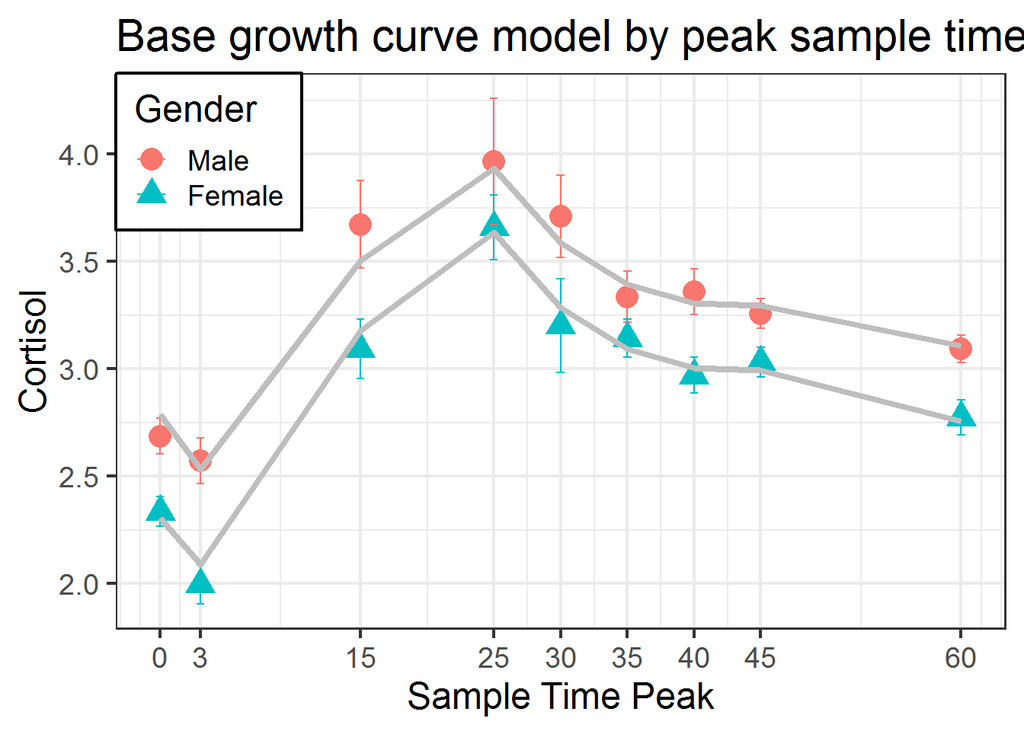

```r
timeticks <- c(0, 3, 15, 25, 30, 35, 40, 45, 60)

cp_long$Sex <- cp_long$gender
cp_long$Sex <- as.factor(cp_long$Sex)
levels(cp_long$Sex) <- c('Male','Female')

ggplot(cp_long, aes(samplepeaknamenum, cortvalue, color=Sex, shape=Sex)) +
stat_summary(fun.y=mean, geom="point", size=5) +
stat_summary(fun.data=mean_se, geom="errorbar",
linetype="solid", width=0.6) +
stat_summary(aes(y=fitted(mod3)), fun.y=mean, geom="line", lwd=1.5, col="gray") +
scale_shape_manual(values=c(16, 17)) +
labs(x="Sample Time Peak", y="Cortisol", color="Gender", shape="Gender") +
theme_bw(base_size=18) +
theme(legend.justification=c(0,1), legend.position=c(0,1),
legend.background=
element_rect(fill="white", color="black")) + scale_x_continuous(breaks=timeticks) + ggtitle("Base growth curve model by peak sample time")
```

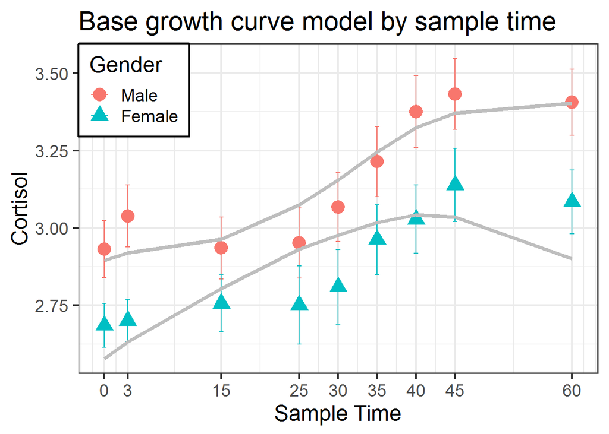

```r
timeticks <- c(0, 3, 15, 25, 30, 35, 40, 45, 60)

cp_long$Sex <- cp_long$gender
cp_long$Sex <- as.factor(cp_long$Sex)
levels(cp_long$Sex) <- c('Male','Female')

ggplot(cp_long, aes(sampletime, cortvalue, color=Sex, shape=Sex)) +
stat_summary(fun.y=mean, geom="point", size=5) +
stat_summary(fun.data=mean_se, geom="errorbar",
linetype="solid", width=0.6) +
stat_summary(aes(y=fitted(mod3)), fun.y=mean, geom="line", lwd=1.5, col="gray") +
scale_shape_manual(values=c(16, 17)) +
labs(x="Sample Time", y="Cortisol",
color="Gender", shape="Gender") +
theme_bw(base_size=18) +
theme(legend.justification=c(0,1), legend.position=c(0,1),
legend.background=
element_rect(fill="white", color="black")) + scale_x_continuous(breaks=timeticks) + ggtitle("Base growth curve model by sample time")
```

```r
cp <- cp_long
cp$sampletime <- as.factor(cp$sampletime)

data_summary <- function(data, varname, groupnames){
  require(plyr)
  summary_func <- function(x, col){
    c(mean = mean(x[[col]], na.rm=TRUE),
      sd = sd(x[[col]], na.rm=TRUE))
  }
  data_sum<-ddply(data, groupnames, .fun=summary_func,
                  varname)
  data_sum <- rename(data_sum, c("mean" = varname))
 return(data_sum)
}

cp1 <- data_summary(cp_long, varname="cortvalue", groupnames=c("gender", "sampletime"))
cp1$sampletime <- as.factor(cp1$sampletime)
head(cp1)
```

```
##   gender sampletime cortvalue        sd
## 1      0          0  2.931103 0.8390133
## 2      0          3  3.038483 0.9112027
## 3      0         15  2.935342 0.9154804
## 4      0         25  2.952568 1.0401512
## 5      0         30  3.067173 1.0068209
## 6      0         35  3.214089 1.0362634
```

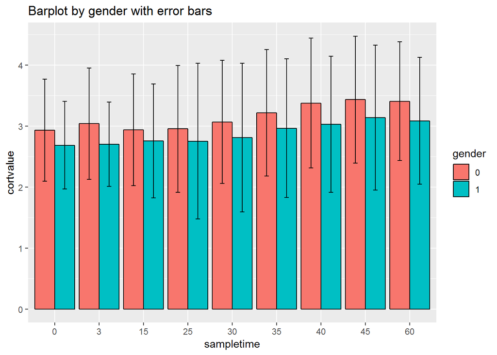

```r
ggplot(cp1, aes(x=sampletime, y=cortvalue, fill=gender)) +
  geom_bar(stat="identity", color="black",
           position=position_dodge()) +
  geom_errorbar(aes(ymin=cortvalue-sd, ymax=cortvalue+sd), width=.2,
                 position=position_dodge(.9)) + ggtitle("Barplot by gender with error bars")
```

```r
rm(cp)
rm(cp1)
rm(timeticks)
rm(data_summary)
```

# Adding emotion to base model

Now that we know that we want to use the third model, we will add emotion (anger, fear, happiness, sadness, and pain). First, let’s remove the old models except for the third model and rename the third model “base”.

```r
rm(mod1)
rm(mod2)
rm(modopt1)
rm(modopt2)
rm(modopt3)
base <- mod3
rm(mod3)
```

## Anger

```r
cp_long$samplepeaknamenum <- as.integer(cp_long$samplepeaknamenum)
cp_long$sampletimetopeak <- as.integer(cp_long$sampletimetopeak)
cp_long$sampletimebeforepeak <- as.integer(cp_long$sampletimebeforepeak)
cp_long$sampletimeafterpeak <- as.integer(cp_long$sampletimeafterpeak)
cp_long$gender <- as.character(cp_long$gender)
cp_long$female <- as.character(cp_long$female)

cp_long$b0 <- cp_long$samplepeaknamenum

test1 <- lm(samplepeaknamenum ~ gender, data = cp_long)
summary(test1)
```

```
##
## Call:
## lm(formula = samplepeaknamenum ~ gender, data = cp_long)
##
## Residuals:
##     Min      1Q  Median      3Q     Max
## -36.542 -11.542   6.157  11.157  26.157
##
## Coefficients:
##             Estimate Std. Error t value Pr(>|t|)
## (Intercept)  36.5422     0.7398  49.394  < 2e-16 ***
## gender1      -2.6990     0.9963  -2.709  0.00682 **
## ---
## Signif. codes:  0 '***' 0.001 '**' 0.01 '*' 0.05 '.' 0.1 ' ' 1
##
## Residual standard error: 20.22 on 1663 degrees of freedom
## Multiple R-squared:  0.004393,   Adjusted R-squared:  0.003795
## F-statistic: 7.338 on 1 and 1663 DF,  p-value: 0.006819
```

```r
cp_long$b1 <- -2.6990

cp_long$b2 <- ifelse((cp_long$gender == "0"), cp_long$sampletimebeforepeak, 0)

cp_long$b3 <- ifelse((cp_long$gender == "0"), cp_long$sampletimeafterpeak, 0)

test2 <- lm(sampletimebeforepeak ~ female, data=cp_long)
summary(test2)
```

```
##
## Call:
## lm(formula = sampletimebeforepeak ~ female, data = cp_long)
##
## Residuals:
##    Min     1Q Median     3Q    Max
## -45.99 -11.01   9.01  14.01  15.99
##
## Coefficients:
##             Estimate Std. Error t value Pr(>|t|)
## (Intercept) -15.9906     0.6471 -24.710   <2e-16 ***
## female1       1.9808     0.8715   2.273   0.0232 *
## ---
## Signif. codes:  0 '***' 0.001 '**' 0.01 '*' 0.05 '.' 0.1 ' ' 1
##
## Residual standard error: 17.69 on 1663 degrees of freedom
## Multiple R-squared:  0.003097,   Adjusted R-squared:  0.002497
## F-statistic: 5.166 on 1 and 1663 DF,  p-value: 0.02316
```

```r
cp_long$b4 <-  1.9808

test3 <- lm(sampletimeafterpeak ~ female, data=cp_long)
summary(test3)
```

```
##
## Call:
## lm(formula = sampletimeafterpeak ~ female, data = cp_long)
##
## Residuals:
##    Min     1Q Median     3Q    Max
## -8.278 -8.278 -7.560  4.440 52.440
##
## Coefficients:
##             Estimate Std. Error t value Pr(>|t|)
## (Intercept)   7.5596     0.5225  14.469   <2e-16 ***
## female1       0.7182     0.7036   1.021    0.308
## ---
## Signif. codes:  0 '***' 0.001 '**' 0.01 '*' 0.05 '.' 0.1 ' ' 1
##
## Residual standard error: 14.28 on 1663 degrees of freedom
## Multiple R-squared:  0.0006261,  Adjusted R-squared:  2.517e-05
## F-statistic: 1.042 on 1 and 1663 DF,  p-value: 0.3075
```

```r
cp_long$b5 <- 0.7182

anger <- lmer(cortvalue ~ (1|b0) + (1|samplepeaknamenum) + (b1*gender) + (b2*sampletimebeforepeak) + (b3*sampletimeafterpeak) + (b4*gender*sampletimebeforepeak) + (b5*gender*sampletimeafterpeak) + angerC, data=cp_long, REML=TRUE)
```

```
## fixed-effect model matrix is rank deficient so dropping 12 columns / coefficients
```

```r
summary(anger)
```

```
## Linear mixed model fit by REML. t-tests use Satterthwaite's method [
## lmerModLmerTest]
## Formula: cortvalue ~ (1 | b0) + (1 | samplepeaknamenum) + (b1 * gender) +
##     (b2 * sampletimebeforepeak) + (b3 * sampletimeafterpeak) +
##     (b4 * gender * sampletimebeforepeak) + (b5 * gender * sampletimeafterpeak) +
##     angerC
##    Data: cp_long
##
## REML criterion at convergence: 4527.9
##
## Scaled residuals:
##     Min      1Q  Median      3Q     Max
## -2.5721 -0.7252 -0.0213  0.6145  7.0798
##
## Random effects:
##  Groups            Name        Variance Std.Dev.
##  b0                (Intercept) 0.06166  0.2483
##  samplepeaknamenum (Intercept) 0.13172  0.3629
##  Residual                      0.83245  0.9124
## Number of obs: 1665, groups:  b0, 9; samplepeaknamenum, 9
##
## Fixed effects:
##                           Estimate Std. Error         df t value Pr(>|t|)
## (Intercept)              3.812e+00  1.654e-01  1.185e+01  23.051 3.29e-11
## gender1                 -4.950e-01  9.113e-02  1.650e+03  -5.432 6.41e-08
## b2                       2.297e-02  7.078e-03  1.649e+03   3.245 0.001200
## sampletimebeforepeak     2.181e-02  2.140e-03  1.656e+03  10.192  < 2e-16
## b3                      -2.456e-02  8.623e-03  1.649e+03  -2.849 0.004444
## sampletimeafterpeak     -1.605e-02  2.717e-03  1.641e+03  -5.907 4.23e-09
## angerC                  -3.629e-02  2.307e-02  1.652e+03  -1.573 0.115965
## b2:sampletimebeforepeak  4.364e-04  1.229e-04  1.649e+03   3.551 0.000394
## b3:sampletimeafterpeak   6.115e-04  1.673e-04  1.649e+03   3.656 0.000264
##
## (Intercept)             ***
## gender1                 ***
## b2                      **
## sampletimebeforepeak    ***
## b3                      **
## sampletimeafterpeak     ***
## angerC
## b2:sampletimebeforepeak ***
## b3:sampletimeafterpeak  ***
## ---
## Signif. codes:  0 '***' 0.001 '**' 0.01 '*' 0.05 '.' 0.1 ' ' 1
##
## Correlation of Fixed Effects:
##             (Intr) gendr1 b2     smpltmb b3     smpltmf angerC b2:smp
## gender1     -0.374
## b2           0.314 -0.698
## smpltmbfrpk -0.026  0.410 -0.264
## b3          -0.276  0.595 -0.459  0.153
## smpltmftrpk -0.030 -0.324  0.152 -0.300  -0.235
## angerC      -0.006  0.056 -0.011  0.012  -0.028  0.029
## b2:smpltmbf  0.246 -0.463  0.909  0.000  -0.335  0.045  -0.005
## b3:smpltmft  0.206 -0.366  0.310 -0.032  -0.901 -0.012   0.008  0.245
## fit warnings:
## fixed-effect model matrix is rank deficient so dropping 12 columns / coefficients
```

```r
rm(test1)
rm(test2)
rm(test3)

cp_long$b0 <- NULL
cp_long$b1 <- NULL
cp_long$b2 <- NULL
cp_long$b3 <- NULL
cp_long$b4 <- NULL
cp_long$b5 <- NULL
```

Anger is not significant.

## Fear

```r
cp_long$samplepeaknamenum <- as.integer(cp_long$samplepeaknamenum)
cp_long$sampletimetopeak <- as.integer(cp_long$sampletimetopeak)
cp_long$sampletimebeforepeak <- as.integer(cp_long$sampletimebeforepeak)
cp_long$sampletimeafterpeak <- as.integer(cp_long$sampletimeafterpeak)
cp_long$gender <- as.character(cp_long$gender)
cp_long$female <- as.character(cp_long$female)

cp_long$b0 <- cp_long$samplepeaknamenum

test1 <- lm(samplepeaknamenum ~ gender, data = cp_long)
summary(test1)
```

```
##
## Call:
## lm(formula = samplepeaknamenum ~ gender, data = cp_long)
##
## Residuals:
##     Min      1Q  Median      3Q     Max
## -36.542 -11.542   6.157  11.157  26.157
##
## Coefficients:
##             Estimate Std. Error t value Pr(>|t|)
## (Intercept)  36.5422     0.7398  49.394  < 2e-16 ***
## gender1      -2.6990     0.9963  -2.709  0.00682 **
## ---
## Signif. codes:  0 '***' 0.001 '**' 0.01 '*' 0.05 '.' 0.1 ' ' 1
##
## Residual standard error: 20.22 on 1663 degrees of freedom
## Multiple R-squared:  0.004393,   Adjusted R-squared:  0.003795
## F-statistic: 7.338 on 1 and 1663 DF,  p-value: 0.006819
```

```r
cp_long$b1 <- -2.6990

cp_long$b2 <- ifelse((cp_long$gender == "0"), cp_long$sampletimebeforepeak, 0)

cp_long$b3 <- ifelse((cp_long$gender == "0"), cp_long$sampletimeafterpeak, 0)

test2 <- lm(sampletimebeforepeak ~ female, data=cp_long)
summary(test2)
```

```
##
## Call:
## lm(formula = sampletimebeforepeak ~ female, data = cp_long)
##
## Residuals:
##    Min     1Q Median     3Q    Max
## -45.99 -11.01   9.01  14.01  15.99
##
## Coefficients:
##             Estimate Std. Error t value Pr(>|t|)
## (Intercept) -15.9906     0.6471 -24.710   <2e-16 ***
## female1       1.9808     0.8715   2.273   0.0232 *
## ---
## Signif. codes:  0 '***' 0.001 '**' 0.01 '*' 0.05 '.' 0.1 ' ' 1
##
## Residual standard error: 17.69 on 1663 degrees of freedom
## Multiple R-squared:  0.003097,   Adjusted R-squared:  0.002497
## F-statistic: 5.166 on 1 and 1663 DF,  p-value: 0.02316
```

```r
cp_long$b4 <-  1.9808

test3 <- lm(sampletimeafterpeak ~ female, data=cp_long)
summary(test3)
```

```
##
## Call:
## lm(formula = sampletimeafterpeak ~ female, data = cp_long)
##
## Residuals:
##    Min     1Q Median     3Q    Max
## -8.278 -8.278 -7.560  4.440 52.440
##
## Coefficients:
##             Estimate Std. Error t value Pr(>|t|)
## (Intercept)   7.5596     0.5225  14.469   <2e-16 ***
## female1       0.7182     0.7036   1.021    0.308
## ---
## Signif. codes:  0 '***' 0.001 '**' 0.01 '*' 0.05 '.' 0.1 ' ' 1
##
## Residual standard error: 14.28 on 1663 degrees of freedom
## Multiple R-squared:  0.0006261,  Adjusted R-squared:  2.517e-05
## F-statistic: 1.042 on 1 and 1663 DF,  p-value: 0.3075
```

```r
cp_long$b5 <- 0.7182

fear <- lmer(cortvalue ~ (1|b0) + (1|samplepeaknamenum) + (b1*gender) + (b2*sampletimebeforepeak) + (b3*sampletimeafterpeak) + (b4*gender*sampletimebeforepeak) + (b5*gender*sampletimeafterpeak) + fearC, data=cp_long, REML=TRUE)
```

```
## fixed-effect model matrix is rank deficient so dropping 12 columns / coefficients
```

```r
summary(fear)
```

```
## Linear mixed model fit by REML. t-tests use Satterthwaite's method [
## lmerModLmerTest]
## Formula: cortvalue ~ (1 | b0) + (1 | samplepeaknamenum) + (b1 * gender) +
##     (b2 * sampletimebeforepeak) + (b3 * sampletimeafterpeak) +
##     (b4 * gender * sampletimebeforepeak) + (b5 * gender * sampletimeafterpeak) +
##     fearC
##    Data: cp_long
##
## REML criterion at convergence: 4528.7
##
## Scaled residuals:
##     Min      1Q  Median      3Q     Max
## -2.5594 -0.7245 -0.0254  0.6142  7.0721
##
## Random effects:
##  Groups            Name        Variance Std.Dev.
##  b0                (Intercept) 0.06183  0.2487
##  samplepeaknamenum (Intercept) 0.13219  0.3636
##  Residual                      0.83279  0.9126
## Number of obs: 1665, groups:  b0, 9; samplepeaknamenum, 9
##
## Fixed effects:
##                           Estimate Std. Error         df t value Pr(>|t|)
## (Intercept)              3.812e+00  1.656e-01  1.184e+01  23.020 3.40e-11
## gender1                 -4.937e-01  9.114e-02  1.650e+03  -5.417 6.97e-08
## b2                       2.285e-02  7.079e-03  1.649e+03   3.227 0.001275
## sampletimebeforepeak     2.185e-02  2.140e-03  1.656e+03  10.209  < 2e-16
## b3                      -2.484e-02  8.622e-03  1.649e+03  -2.881 0.004019
## sampletimeafterpeak     -1.597e-02  2.717e-03  1.641e+03  -5.880 4.97e-09
## fearC                   -3.055e-02  2.295e-02  1.650e+03  -1.331 0.183299
## b2:sampletimebeforepeak  4.356e-04  1.229e-04  1.649e+03   3.544 0.000405
## b3:sampletimeafterpeak   6.137e-04  1.673e-04  1.649e+03   3.669 0.000251
##
## (Intercept)             ***
## gender1                 ***
## b2                      **
## sampletimebeforepeak    ***
## b3                      **
## sampletimeafterpeak     ***
## fearC
## b2:sampletimebeforepeak ***
## b3:sampletimeafterpeak  ***
## ---
## Signif. codes:  0 '***' 0.001 '**' 0.01 '*' 0.05 '.' 0.1 ' ' 1
##
## Correlation of Fixed Effects:
##             (Intr) gendr1 b2     smpltmb b3     smpltmf fearC  b2:smp
## gender1     -0.374
## b2           0.314 -0.698
## smpltmbfrpk -0.026  0.409 -0.263
## b3          -0.276  0.596 -0.460  0.153
## smpltmftrpk -0.029 -0.325  0.153 -0.300  -0.234
## fearC       -0.008  0.056  0.000  0.000  -0.010  0.014
## b2:smpltmbf  0.245 -0.463  0.909  0.000  -0.335  0.045  -0.001
## b3:smpltmft  0.206 -0.367  0.310 -0.032  -0.901 -0.012   0.000  0.245
## fit warnings:
## fixed-effect model matrix is rank deficient so dropping 12 columns / coefficients
```

```r
rm(test1)
rm(test2)
rm(test3)

cp_long$b0 <- NULL
cp_long$b1 <- NULL
cp_long$b2 <- NULL
cp_long$b3 <- NULL
cp_long$b4 <- NULL
cp_long$b5 <- NULL
```

Fear is not significant.

## Happiness

```r
cp_long$samplepeaknamenum <- as.integer(cp_long$samplepeaknamenum)
cp_long$sampletimetopeak <- as.integer(cp_long$sampletimetopeak)
cp_long$sampletimebeforepeak <- as.integer(cp_long$sampletimebeforepeak)
cp_long$sampletimeafterpeak <- as.integer(cp_long$sampletimeafterpeak)
cp_long$gender <- as.character(cp_long$gender)
cp_long$female <- as.character(cp_long$female)

cp_long$b0 <- cp_long$samplepeaknamenum

test1 <- lm(samplepeaknamenum ~ gender, data = cp_long)
summary(test1)
```

```
##
## Call:
## lm(formula = samplepeaknamenum ~ gender, data = cp_long)
##
## Residuals:
##     Min      1Q  Median      3Q     Max
## -36.542 -11.542   6.157  11.157  26.157
##
## Coefficients:
##             Estimate Std. Error t value Pr(>|t|)
## (Intercept)  36.5422     0.7398  49.394  < 2e-16 ***
## gender1      -2.6990     0.9963  -2.709  0.00682 **
## ---
## Signif. codes:  0 '***' 0.001 '**' 0.01 '*' 0.05 '.' 0.1 ' ' 1
##
## Residual standard error: 20.22 on 1663 degrees of freedom
## Multiple R-squared:  0.004393,   Adjusted R-squared:  0.003795
## F-statistic: 7.338 on 1 and 1663 DF,  p-value: 0.006819
```

```r
cp_long$b1 <- -2.6990

cp_long$b2 <- ifelse((cp_long$gender == "0"), cp_long$sampletimebeforepeak, 0)

cp_long$b3 <- ifelse((cp_long$gender == "0"), cp_long$sampletimeafterpeak, 0)

test2 <- lm(sampletimebeforepeak ~ female, data=cp_long)
summary(test2)
```

```
##
## Call:
## lm(formula = sampletimebeforepeak ~ female, data = cp_long)
##
## Residuals:
##    Min     1Q Median     3Q    Max
## -45.99 -11.01   9.01  14.01  15.99
##
## Coefficients:
##             Estimate Std. Error t value Pr(>|t|)
## (Intercept) -15.9906     0.6471 -24.710   <2e-16 ***
## female1       1.9808     0.8715   2.273   0.0232 *
## ---
## Signif. codes:  0 '***' 0.001 '**' 0.01 '*' 0.05 '.' 0.1 ' ' 1
##
## Residual standard error: 17.69 on 1663 degrees of freedom
## Multiple R-squared:  0.003097,   Adjusted R-squared:  0.002497
## F-statistic: 5.166 on 1 and 1663 DF,  p-value: 0.02316
```

```r
cp_long$b4 <-  1.9808

test3 <- lm(sampletimeafterpeak ~ female, data=cp_long)
summary(test3)
```

```
##
## Call:
## lm(formula = sampletimeafterpeak ~ female, data = cp_long)
##
## Residuals:
##    Min     1Q Median     3Q    Max
## -8.278 -8.278 -7.560  4.440 52.440
##
## Coefficients:
##             Estimate Std. Error t value Pr(>|t|)
## (Intercept)   7.5596     0.5225  14.469   <2e-16 ***
## female1       0.7182     0.7036   1.021    0.308
## ---
## Signif. codes:  0 '***' 0.001 '**' 0.01 '*' 0.05 '.' 0.1 ' ' 1
##
## Residual standard error: 14.28 on 1663 degrees of freedom
## Multiple R-squared:  0.0006261,  Adjusted R-squared:  2.517e-05
## F-statistic: 1.042 on 1 and 1663 DF,  p-value: 0.3075
```

```r
cp_long$b5 <- 0.7182

happy <- lmer(cortvalue ~ (1|b0) + (1|samplepeaknamenum) + (b1*gender) + (b2*sampletimebeforepeak) + (b3*sampletimeafterpeak) + (b4*gender*sampletimebeforepeak) + (b5*gender*sampletimeafterpeak) + happinessC, data=cp_long, REML=TRUE)
```

```
## fixed-effect model matrix is rank deficient so dropping 12 columns / coefficients
```

```r
summary(happy)
```

```
## Linear mixed model fit by REML. t-tests use Satterthwaite's method [
## lmerModLmerTest]
## Formula: cortvalue ~ (1 | b0) + (1 | samplepeaknamenum) + (b1 * gender) +
##     (b2 * sampletimebeforepeak) + (b3 * sampletimeafterpeak) +
##     (b4 * gender * sampletimebeforepeak) + (b5 * gender * sampletimeafterpeak) +
##     happinessC
##    Data: cp_long
##
## REML criterion at convergence: 4530.3
##
## Scaled residuals:
##     Min      1Q  Median      3Q     Max
## -2.5130 -0.7152 -0.0236  0.6241  7.1112
##
## Random effects:
##  Groups            Name        Variance Std.Dev.
##  b0                (Intercept) 0.06177  0.2485
##  samplepeaknamenum (Intercept) 0.13204  0.3634
##  Residual                      0.83364  0.9130
## Number of obs: 1665, groups:  b0, 9; samplepeaknamenum, 9
##
## Fixed effects:
##                           Estimate Std. Error         df t value Pr(>|t|)
## (Intercept)              3.813e+00  1.657e-01  1.189e+01  23.009 3.19e-11
## gender1                 -4.899e-01  9.158e-02  1.650e+03  -5.349 1.01e-07
## b2                       2.286e-02  7.083e-03  1.649e+03   3.227 0.001274
## sampletimebeforepeak     2.184e-02  2.142e-03  1.656e+03  10.199  < 2e-16
## b3                      -2.498e-02  8.626e-03  1.649e+03  -2.896 0.003835
## sampletimeafterpeak     -1.592e-02  2.718e-03  1.641e+03  -5.857 5.68e-09
## happinessC               6.962e-03  2.318e-02  1.651e+03   0.300 0.763994
## b2:sampletimebeforepeak  4.354e-04  1.230e-04  1.649e+03   3.540 0.000411
## b3:sampletimeafterpeak   6.142e-04  1.674e-04  1.649e+03   3.670 0.000250
##
## (Intercept)             ***
## gender1                 ***
## b2                      **
## sampletimebeforepeak    ***
## b3                      **
## sampletimeafterpeak     ***
## happinessC
## b2:sampletimebeforepeak ***
## b3:sampletimeafterpeak  ***
## ---
## Signif. codes:  0 '***' 0.001 '**' 0.01 '*' 0.05 '.' 0.1 ' ' 1
##
## Correlation of Fixed Effects:
##             (Intr) gendr1 b2     smpltmb b3     smpltmf hppnsC b2:smp
## gender1     -0.377
## b2           0.314 -0.695
## smpltmbfrpk -0.026  0.408 -0.264
## b3          -0.277  0.595 -0.460  0.153
## smpltmftrpk -0.029 -0.325  0.153 -0.300  -0.234
## happinessC   0.044 -0.108  0.007 -0.013  -0.011  0.006
## b2:smpltmbf  0.245 -0.461  0.909  0.000  -0.335  0.045  -0.003
## b3:smpltmft  0.206 -0.366  0.310 -0.032  -0.901 -0.012   0.009  0.245
## fit warnings:
## fixed-effect model matrix is rank deficient so dropping 12 columns / coefficients
```

```r
rm(test1)
rm(test2)
rm(test3)

cp_long$b0 <- NULL
cp_long$b1 <- NULL
cp_long$b2 <- NULL
cp_long$b3 <- NULL
cp_long$b4 <- NULL
cp_long$b5 <- NULL
```

Happiness is not significant.

## Sadness

```r
cp_long$samplepeaknamenum <- as.integer(cp_long$samplepeaknamenum)
cp_long$sampletimetopeak <- as.integer(cp_long$sampletimetopeak)
cp_long$sampletimebeforepeak <- as.integer(cp_long$sampletimebeforepeak)
cp_long$sampletimeafterpeak <- as.integer(cp_long$sampletimeafterpeak)
cp_long$gender <- as.character(cp_long$gender)
cp_long$female <- as.character(cp_long$female)

cp_long$b0 <- cp_long$samplepeaknamenum

test1 <- lm(samplepeaknamenum ~ gender, data = cp_long)
summary(test1)
```

```
##
## Call:
## lm(formula = samplepeaknamenum ~ gender, data = cp_long)
##
## Residuals:
##     Min      1Q  Median      3Q     Max
## -36.542 -11.542   6.157  11.157  26.157
##
## Coefficients:
##             Estimate Std. Error t value Pr(>|t|)
## (Intercept)  36.5422     0.7398  49.394  < 2e-16 ***
## gender1      -2.6990     0.9963  -2.709  0.00682 **
## ---
## Signif. codes:  0 '***' 0.001 '**' 0.01 '*' 0.05 '.' 0.1 ' ' 1
##
## Residual standard error: 20.22 on 1663 degrees of freedom
## Multiple R-squared:  0.004393,   Adjusted R-squared:  0.003795
## F-statistic: 7.338 on 1 and 1663 DF,  p-value: 0.006819
```

```r
cp_long$b1 <- -2.6990

cp_long$b2 <- ifelse((cp_long$gender == "0"), cp_long$sampletimebeforepeak, 0)

cp_long$b3 <- ifelse((cp_long$gender == "0"), cp_long$sampletimeafterpeak, 0)

test2 <- lm(sampletimebeforepeak ~ female, data=cp_long)
summary(test2)
```

```
##
## Call:
## lm(formula = sampletimebeforepeak ~ female, data = cp_long)
##
## Residuals:
##    Min     1Q Median     3Q    Max
## -45.99 -11.01   9.01  14.01  15.99
##
## Coefficients:
##             Estimate Std. Error t value Pr(>|t|)
## (Intercept) -15.9906     0.6471 -24.710   <2e-16 ***
## female1       1.9808     0.8715   2.273   0.0232 *
## ---
## Signif. codes:  0 '***' 0.001 '**' 0.01 '*' 0.05 '.' 0.1 ' ' 1
##
## Residual standard error: 17.69 on 1663 degrees of freedom
## Multiple R-squared:  0.003097,   Adjusted R-squared:  0.002497
## F-statistic: 5.166 on 1 and 1663 DF,  p-value: 0.02316
```

```r
cp_long$b4 <-  1.9808

test3 <- lm(sampletimeafterpeak ~ female, data=cp_long)
summary(test3)
```

```
##
## Call:
## lm(formula = sampletimeafterpeak ~ female, data = cp_long)
##
## Residuals:
##    Min     1Q Median     3Q    Max
## -8.278 -8.278 -7.560  4.440 52.440
##
## Coefficients:
##             Estimate Std. Error t value Pr(>|t|)
## (Intercept)   7.5596     0.5225  14.469   <2e-16 ***
## female1       0.7182     0.7036   1.021    0.308
## ---
## Signif. codes:  0 '***' 0.001 '**' 0.01 '*' 0.05 '.' 0.1 ' ' 1
##
## Residual standard error: 14.28 on 1663 degrees of freedom
## Multiple R-squared:  0.0006261,  Adjusted R-squared:  2.517e-05
## F-statistic: 1.042 on 1 and 1663 DF,  p-value: 0.3075
```

```r
cp_long$b5 <- 0.7182

sad <- lmer(cortvalue ~ (1|b0) + (1|samplepeaknamenum) + (b1*gender) + (b2*sampletimebeforepeak) + (b3*sampletimeafterpeak) + (b4*gender*sampletimebeforepeak) + (b5*gender*sampletimeafterpeak) + sadnessC, data=cp_long, REML=TRUE)
```

```
## fixed-effect model matrix is rank deficient so dropping 12 columns / coefficients
```

```r
summary(sad)
```

```
## Linear mixed model fit by REML. t-tests use Satterthwaite's method [
## lmerModLmerTest]
## Formula: cortvalue ~ (1 | b0) + (1 | samplepeaknamenum) + (b1 * gender) +
##     (b2 * sampletimebeforepeak) + (b3 * sampletimeafterpeak) +
##     (b4 * gender * sampletimebeforepeak) + (b5 * gender * sampletimeafterpeak) +
##     sadnessC
##    Data: cp_long
##
## REML criterion at convergence: 4522.8
##
## Scaled residuals:
##     Min      1Q  Median      3Q     Max
## -2.6387 -0.7197 -0.0330  0.6271  7.0588
##
## Random effects:
##  Groups            Name        Variance Std.Dev.
##  b0                (Intercept) 0.06194  0.2489
##  samplepeaknamenum (Intercept) 0.13264  0.3642
##  Residual                      0.82979  0.9109
## Number of obs: 1665, groups:  b0, 9; samplepeaknamenum, 9
##
## Fixed effects:
##                           Estimate Std. Error         df t value Pr(>|t|)
## (Intercept)              3.815e+00  1.657e-01  1.181e+01  23.017 3.53e-11
## gender1                 -4.943e-01  9.088e-02  1.650e+03  -5.440 6.14e-08
## b2                       2.291e-02  7.067e-03  1.649e+03   3.242 0.001211
## sampletimebeforepeak     2.177e-02  2.137e-03  1.656e+03  10.190  < 2e-16
## b3                      -2.518e-02  8.606e-03  1.649e+03  -2.925 0.003487
## sampletimeafterpeak     -1.584e-02  2.712e-03  1.642e+03  -5.842 6.22e-09
## sadnessC                -6.310e-02  2.273e-02  1.650e+03  -2.776 0.005566
## b2:sampletimebeforepeak  4.334e-04  1.227e-04  1.649e+03   3.532 0.000424
## b3:sampletimeafterpeak   6.150e-04  1.670e-04  1.649e+03   3.683 0.000238
##
## (Intercept)             ***
## gender1                 ***
## b2                      **
## sampletimebeforepeak    ***
## b3                      **
## sampletimeafterpeak     ***
## sadnessC                **
## b2:sampletimebeforepeak ***
## b3:sampletimeafterpeak  ***
## ---
## Signif. codes:  0 '***' 0.001 '**' 0.01 '*' 0.05 '.' 0.1 ' ' 1
##
## Correlation of Fixed Effects:
##             (Intr) gendr1 b2     smpltmb b3     smpltmf sdnssC b2:smp
## gender1     -0.373
## b2           0.313 -0.699
## smpltmbfrpk -0.026  0.410 -0.264
## b3          -0.276  0.597 -0.460  0.153
## smpltmftrpk -0.029 -0.326  0.153 -0.300  -0.234
## sadnessC    -0.009  0.029 -0.003  0.013   0.010 -0.010
## b2:smpltmbf  0.245 -0.463  0.909  0.000  -0.335  0.045   0.006
## b3:smpltmft  0.205 -0.367  0.310 -0.032  -0.901 -0.012  -0.003  0.245
## fit warnings:
## fixed-effect model matrix is rank deficient so dropping 12 columns / coefficients
```

```r
rm(test1)
rm(test2)
rm(test3)

cp_long$b0 <- NULL
cp_long$b1 <- NULL
cp_long$b2 <- NULL
cp_long$b3 <- NULL
cp_long$b4 <- NULL
cp_long$b5 <- NULL
```

Sadness is significant with p = 0.005566.

## Pain

```r
cp_long$samplepeaknamenum <- as.integer(cp_long$samplepeaknamenum)
cp_long$sampletimetopeak <- as.integer(cp_long$sampletimetopeak)
cp_long$sampletimebeforepeak <- as.integer(cp_long$sampletimebeforepeak)
cp_long$sampletimeafterpeak <- as.integer(cp_long$sampletimeafterpeak)
cp_long$gender <- as.character(cp_long$gender)
cp_long$female <- as.character(cp_long$female)

cp_long$b0 <- cp_long$samplepeaknamenum

test1 <- lm(samplepeaknamenum ~ gender, data = cp_long)
summary(test1)
```

```
##
## Call:
## lm(formula = samplepeaknamenum ~ gender, data = cp_long)
##
## Residuals:
##     Min      1Q  Median      3Q     Max
## -36.542 -11.542   6.157  11.157  26.157
##
## Coefficients:
##             Estimate Std. Error t value Pr(>|t|)
## (Intercept)  36.5422     0.7398  49.394  < 2e-16 ***
## gender1      -2.6990     0.9963  -2.709  0.00682 **
## ---
## Signif. codes:  0 '***' 0.001 '**' 0.01 '*' 0.05 '.' 0.1 ' ' 1
##
## Residual standard error: 20.22 on 1663 degrees of freedom
## Multiple R-squared:  0.004393,   Adjusted R-squared:  0.003795
## F-statistic: 7.338 on 1 and 1663 DF,  p-value: 0.006819
```

```r
cp_long$b1 <- -2.6990

cp_long$b2 <- ifelse((cp_long$gender == "0"), cp_long$sampletimebeforepeak, 0)

cp_long$b3 <- ifelse((cp_long$gender == "0"), cp_long$sampletimeafterpeak, 0)

test2 <- lm(sampletimebeforepeak ~ female, data=cp_long)
summary(test2)
```

```
##
## Call:
## lm(formula = sampletimebeforepeak ~ female, data = cp_long)
##
## Residuals:
##    Min     1Q Median     3Q    Max
## -45.99 -11.01   9.01  14.01  15.99
##
## Coefficients:
##             Estimate Std. Error t value Pr(>|t|)
## (Intercept) -15.9906     0.6471 -24.710   <2e-16 ***
## female1       1.9808     0.8715   2.273   0.0232 *
## ---
## Signif. codes:  0 '***' 0.001 '**' 0.01 '*' 0.05 '.' 0.1 ' ' 1
##
## Residual standard error: 17.69 on 1663 degrees of freedom
## Multiple R-squared:  0.003097,   Adjusted R-squared:  0.002497
## F-statistic: 5.166 on 1 and 1663 DF,  p-value: 0.02316
```

```r
cp_long$b4 <-  1.9808

test3 <- lm(sampletimeafterpeak ~ female, data=cp_long)
summary(test3)
```

```
##
## Call:
## lm(formula = sampletimeafterpeak ~ female, data = cp_long)
##
## Residuals:
##    Min     1Q Median     3Q    Max
## -8.278 -8.278 -7.560  4.440 52.440
##
## Coefficients:
##             Estimate Std. Error t value Pr(>|t|)
## (Intercept)   7.5596     0.5225  14.469   <2e-16 ***
## female1       0.7182     0.7036   1.021    0.308
## ---
## Signif. codes:  0 '***' 0.001 '**' 0.01 '*' 0.05 '.' 0.1 ' ' 1
##
## Residual standard error: 14.28 on 1663 degrees of freedom
## Multiple R-squared:  0.0006261,  Adjusted R-squared:  2.517e-05
## F-statistic: 1.042 on 1 and 1663 DF,  p-value: 0.3075
```

```r
cp_long$b5 <- 0.7182

pain <- lmer(cortvalue ~ (1|b0) + (1|samplepeaknamenum) + (b1*gender) + (b2*sampletimebeforepeak) + (b3*sampletimeafterpeak) + (b4*gender*sampletimebeforepeak) + (b5*gender*sampletimeafterpeak) + painC, data=cp_long, REML=TRUE)
```

```
## fixed-effect model matrix is rank deficient so dropping 12 columns / coefficients
```

```r
summary(pain)
```

```
## Linear mixed model fit by REML. t-tests use Satterthwaite's method [
## lmerModLmerTest]
## Formula: cortvalue ~ (1 | b0) + (1 | samplepeaknamenum) + (b1 * gender) +
##     (b2 * sampletimebeforepeak) + (b3 * sampletimeafterpeak) +
##     (b4 * gender * sampletimebeforepeak) + (b5 * gender * sampletimeafterpeak) +
##     painC
##    Data: cp_long
##
## REML criterion at convergence: 4529
##
## Scaled residuals:
##     Min      1Q  Median      3Q     Max
## -2.5657 -0.7219 -0.0233  0.6173  7.0803
##
## Random effects:
##  Groups            Name        Variance Std.Dev.
##  b0                (Intercept) 0.06193  0.2489
##  samplepeaknamenum (Intercept) 0.13088  0.3618
##  Residual                      0.83299  0.9127
## Number of obs: 1665, groups:  b0, 9; samplepeaknamenum, 9
##
## Fixed effects:
##                           Estimate Std. Error         df t value Pr(>|t|)
## (Intercept)              3.809e+00  1.652e-01  1.187e+01  23.056 3.21e-11
## gender1                 -4.899e-01  9.105e-02  1.650e+03  -5.381 8.48e-08
## b2                       2.289e-02  7.080e-03  1.649e+03   3.233 0.001250
## sampletimebeforepeak     2.183e-02  2.141e-03  1.656e+03  10.199  < 2e-16
## b3                      -2.471e-02  8.625e-03  1.649e+03  -2.865 0.004219
## sampletimeafterpeak     -1.599e-02  2.717e-03  1.641e+03  -5.883 4.86e-09
## painC                   -2.756e-02  2.307e-02  1.654e+03  -1.195 0.232293
## b2:sampletimebeforepeak  4.359e-04  1.229e-04  1.649e+03   3.545 0.000403
## b3:sampletimeafterpeak   6.115e-04  1.673e-04  1.649e+03   3.655 0.000265
##
## (Intercept)             ***
## gender1                 ***
## b2                      **
## sampletimebeforepeak    ***
## b3                      **
## sampletimeafterpeak     ***
## painC
## b2:sampletimebeforepeak ***
## b3:sampletimeafterpeak  ***
## ---
## Signif. codes:  0 '***' 0.001 '**' 0.01 '*' 0.05 '.' 0.1 ' ' 1
##
## Correlation of Fixed Effects:
##             (Intr) gendr1 b2     smpltmb b3     smpltmf painC  b2:smp
## gender1     -0.375
## b2           0.315 -0.699
## smpltmbfrpk -0.026  0.410 -0.264
## b3          -0.277  0.596 -0.460  0.153
## smpltmftrpk -0.029 -0.325  0.153 -0.300  -0.235
## painC        0.008  0.028 -0.005  0.007  -0.023  0.018
## b2:smpltmbf  0.246 -0.463  0.909  0.000  -0.335  0.045  -0.003
## b3:smpltmft  0.206 -0.367  0.310 -0.032  -0.901 -0.012   0.011  0.245
## fit warnings:
## fixed-effect model matrix is rank deficient so dropping 12 columns / coefficients
## convergence code: 0
## unable to evaluate scaled gradient
## Model failed to converge: degenerate  Hessian with 1 negative eigenvalues
```

```r
rm(test1)
rm(test2)
rm(test3)

cp_long$b0 <- NULL
cp_long$b1 <- NULL
cp_long$b2 <- NULL
cp_long$b3 <- NULL
cp_long$b4 <- NULL
cp_long$b5 <- NULL
```

Pain is not significant.

## Emotional model findings and conclusions

It looks like the only emotion that is significant is sadness. Therefore, let’s examine sadness in depth more. First, let’s remove the other emotions.

```r
rm(anger)
rm(fear)
rm(happy)
rm(pain)
```

In our dataset, we have CTQ Total Sum (“ctqsumC”). Let’s see if adding CTQ to “sad” will make any difference. We will use the zero-centered version of CTQ Total Sum.

```r
cp_long$samplepeaknamenum <- as.integer(cp_long$samplepeaknamenum)
cp_long$sampletimetopeak <- as.integer(cp_long$sampletimetopeak)
cp_long$sampletimebeforepeak <- as.integer(cp_long$sampletimebeforepeak)
cp_long$sampletimeafterpeak <- as.integer(cp_long$sampletimeafterpeak)
cp_long$gender <- as.character(cp_long$gender)
cp_long$female <- as.character(cp_long$female)

cp_long$b0 <- cp_long$samplepeaknamenum

test1 <- lm(samplepeaknamenum ~ gender, data = cp_long)
summary(test1)
```

```
##
## Call:
## lm(formula = samplepeaknamenum ~ gender, data = cp_long)
##
## Residuals:
##     Min      1Q  Median      3Q     Max
## -36.542 -11.542   6.157  11.157  26.157
##
## Coefficients:
##             Estimate Std. Error t value Pr(>|t|)
## (Intercept)  36.5422     0.7398  49.394  < 2e-16 ***
## gender1      -2.6990     0.9963  -2.709  0.00682 **
## ---
## Signif. codes:  0 '***' 0.001 '**' 0.01 '*' 0.05 '.' 0.1 ' ' 1
##
## Residual standard error: 20.22 on 1663 degrees of freedom
## Multiple R-squared:  0.004393,   Adjusted R-squared:  0.003795
## F-statistic: 7.338 on 1 and 1663 DF,  p-value: 0.006819
```

```r
cp_long$b1 <- -2.6990

cp_long$b2 <- ifelse((cp_long$gender == "0"), cp_long$sampletimebeforepeak, 0)

cp_long$b3 <- ifelse((cp_long$gender == "0"), cp_long$sampletimeafterpeak, 0)

test2 <- lm(sampletimebeforepeak ~ female, data=cp_long)
summary(test2)
```

```
##
## Call:
## lm(formula = sampletimebeforepeak ~ female, data = cp_long)
##
## Residuals:
##    Min     1Q Median     3Q    Max
## -45.99 -11.01   9.01  14.01  15.99
##
## Coefficients:
##             Estimate Std. Error t value Pr(>|t|)
## (Intercept) -15.9906     0.6471 -24.710   <2e-16 ***
## female1       1.9808     0.8715   2.273   0.0232 *
## ---
## Signif. codes:  0 '***' 0.001 '**' 0.01 '*' 0.05 '.' 0.1 ' ' 1
##
## Residual standard error: 17.69 on 1663 degrees of freedom
## Multiple R-squared:  0.003097,   Adjusted R-squared:  0.002497
## F-statistic: 5.166 on 1 and 1663 DF,  p-value: 0.02316
```

```r
cp_long$b4 <-  1.9808

test3 <- lm(sampletimeafterpeak ~ female, data=cp_long)
summary(test3)
```

```
##
## Call:
## lm(formula = sampletimeafterpeak ~ female, data = cp_long)
##
## Residuals:
##    Min     1Q Median     3Q    Max
## -8.278 -8.278 -7.560  4.440 52.440
##
## Coefficients:
##             Estimate Std. Error t value Pr(>|t|)
## (Intercept)   7.5596     0.5225  14.469   <2e-16 ***
## female1       0.7182     0.7036   1.021    0.308
## ---
## Signif. codes:  0 '***' 0.001 '**' 0.01 '*' 0.05 '.' 0.1 ' ' 1
##
## Residual standard error: 14.28 on 1663 degrees of freedom
## Multiple R-squared:  0.0006261,  Adjusted R-squared:  2.517e-05
## F-statistic: 1.042 on 1 and 1663 DF,  p-value: 0.3075
```

```r
cp_long$b5 <- 0.7182

ctq <- lmer(cortvalue ~ (1|b0) + (1|samplepeaknamenum) + (b1*gender) + (b2*sampletimebeforepeak) + (b3*sampletimeafterpeak) + (b4*gender*sampletimebeforepeak) + (b5*gender*sampletimeafterpeak) + ctqsumC, data=cp_long, REML=TRUE)
```

```
## fixed-effect model matrix is rank deficient so dropping 12 columns / coefficients
```

```r
summary(ctq)
```

```
## Linear mixed model fit by REML. t-tests use Satterthwaite's method [
## lmerModLmerTest]
## Formula: cortvalue ~ (1 | b0) + (1 | samplepeaknamenum) + (b1 * gender) +
##     (b2 * sampletimebeforepeak) + (b3 * sampletimeafterpeak) +
##     (b4 * gender * sampletimebeforepeak) + (b5 * gender * sampletimeafterpeak) +
##     ctqsumC
##    Data: cp_long
##
## REML criterion at convergence: 4529.9
##
## Scaled residuals:
##     Min      1Q  Median      3Q     Max
## -2.5225 -0.7091 -0.0250  0.6153  7.0798
##
## Random effects:
##  Groups            Name        Variance Std.Dev.
##  b0                (Intercept) 0.06161  0.2482
##  samplepeaknamenum (Intercept) 0.12826  0.3581
##  Residual                      0.83351  0.9130
## Number of obs: 1665, groups:  b0, 9; samplepeaknamenum, 9
##
## Fixed effects:
##                           Estimate Std. Error         df t value Pr(>|t|)
## (Intercept)              3.808e+00  1.643e-01  1.190e+01  23.181 2.85e-11
## gender1                 -4.854e-01  9.106e-02  1.650e+03  -5.330 1.12e-07
## b2                       2.284e-02  7.082e-03  1.649e+03   3.225 0.001286
## sampletimebeforepeak     2.183e-02  2.141e-03  1.656e+03  10.197  < 2e-16
## b3                      -2.491e-02  8.625e-03  1.649e+03  -2.888 0.003930
## sampletimeafterpeak     -1.591e-02  2.718e-03  1.640e+03  -5.855 5.75e-09
## ctqsumC                  1.653e-02  2.312e-02  1.655e+03   0.715 0.474776
## b2:sampletimebeforepeak  4.350e-04  1.230e-04  1.649e+03   3.537 0.000416
## b3:sampletimeafterpeak   6.119e-04  1.674e-04  1.649e+03   3.656 0.000264
##
## (Intercept)             ***
## gender1                 ***
## b2                      **
## sampletimebeforepeak    ***
## b3                      **
## sampletimeafterpeak     ***
## ctqsumC
## b2:sampletimebeforepeak ***
## b3:sampletimeafterpeak  ***
## ---
## Signif. codes:  0 '***' 0.001 '**' 0.01 '*' 0.05 '.' 0.1 ' ' 1
##
## Correlation of Fixed Effects:
##             (Intr) gendr1 b2     smpltmb b3     smpltmf ctqsmC b2:smp
## gender1     -0.378
## b2           0.316 -0.699
## smpltmbfrpk -0.026  0.409 -0.263
## b3          -0.279  0.597 -0.460  0.153
## smpltmftrpk -0.030 -0.326  0.153 -0.300  -0.234
## ctqsumC     -0.024  0.022  0.000 -0.009   0.007  0.013
## b2:smpltmbf  0.248 -0.464  0.909  0.000  -0.335  0.045  -0.005
## b3:smpltmft  0.208 -0.367  0.310 -0.031  -0.901 -0.012  -0.015  0.245
## fit warnings:
## fixed-effect model matrix is rank deficient so dropping 12 columns / coefficients
```

```r
sadctq <- lmer(cortvalue ~ (1|b0) + (1|samplepeaknamenum) + (b1*gender) + (b2*sampletimebeforepeak) + (b3*sampletimeafterpeak) + (b4*gender*sampletimebeforepeak) + (b5*gender*sampletimeafterpeak) + sadnessC + ctqsumC, data=cp_long, REML=TRUE)
```

```
## fixed-effect model matrix is rank deficient so dropping 12 columns / coefficients
```

```r
summary(sadctq)
```

```
## Linear mixed model fit by REML. t-tests use Satterthwaite's method [
## lmerModLmerTest]
## Formula: cortvalue ~ (1 | b0) + (1 | samplepeaknamenum) + (b1 * gender) +
##     (b2 * sampletimebeforepeak) + (b3 * sampletimeafterpeak) +
##     (b4 * gender * sampletimebeforepeak) + (b5 * gender * sampletimeafterpeak) +
##     sadnessC + ctqsumC
##    Data: cp_long
##
## REML criterion at convergence: 4527.8
##
## Scaled residuals:
##     Min      1Q  Median      3Q     Max
## -2.6400 -0.7157 -0.0262  0.6239  7.0303
##
## Random effects:
##  Groups            Name        Variance Std.Dev.
##  b0                (Intercept) 0.06216  0.2493
##  samplepeaknamenum (Intercept) 0.12789  0.3576
##  Residual                      0.83005  0.9111
## Number of obs: 1665, groups:  b0, 9; samplepeaknamenum, 9
##
## Fixed effects:
##                           Estimate Std. Error         df t value Pr(>|t|)
## (Intercept)              3.811e+00  1.643e-01  1.189e+01  23.204 2.88e-11
## gender1                 -4.926e-01  9.091e-02  1.649e+03  -5.419 6.88e-08
## b2                       2.290e-02  7.068e-03  1.648e+03   3.240 0.001218
## sampletimebeforepeak     2.175e-02  2.137e-03  1.655e+03  10.179  < 2e-16
## b3                      -2.513e-02  8.608e-03  1.648e+03  -2.920 0.003551
## sampletimeafterpeak     -1.583e-02  2.712e-03  1.640e+03  -5.836 6.45e-09
## sadnessC                -6.384e-02  2.275e-02  1.649e+03  -2.806 0.005076
## ctqsumC                  1.908e-02  2.309e-02  1.654e+03   0.826 0.408809
## b2:sampletimebeforepeak  4.328e-04  1.227e-04  1.648e+03   3.526 0.000433
## b3:sampletimeafterpeak   6.130e-04  1.670e-04  1.648e+03   3.670 0.000250
##
## (Intercept)             ***
## gender1                 ***
## b2                      **
## sampletimebeforepeak    ***
## b3                      **
## sampletimeafterpeak     ***
```

[output cut: 15 more lines]

```
## ctqsumC     -0.024  0.021  0.000 -0.010   0.006  0.013  -0.040
## b2:smpltmbf  0.247 -0.463  0.909  0.000  -0.335  0.045   0.006 -0.005
## b3:smpltmft  0.208 -0.367  0.310 -0.032  -0.901 -0.012  -0.002 -0.015
##             b2:smp
## gender1
## b2
## smpltmbfrpk
## b3
## smpltmftrpk
## sadnessC
## ctqsumC
## b2:smpltmbf
## b3:smpltmft  0.245
## fit warnings:
## fixed-effect model matrix is rank deficient so dropping 12 columns / coefficients
```

```r
rm(test1)
rm(test2)
rm(test3)

cp_long$b0 <- NULL
cp_long$b1 <- NULL
cp_long$b2 <- NULL
cp_long$b3 <- NULL
cp_long$b4 <- NULL
cp_long$b5 <- NULL
```

CTQ is not a significant predictor of cortisol, while sadness remains significant. We can test fit improvement among our models by using anova().

```r
anova(base, sad, ctq, sadctq)
```

```
## refitting model(s) with ML (instead of REML)
```

```
## Data: cp_long
## Models:
## base: cortvalue ~ (1 | b0) + (1 | samplepeaknamenum) + (b1 * gender) +
## base:     (b2 * sampletimebeforepeak) + (b3 * sampletimeafterpeak) +
## base:     (b4 * gender * sampletimebeforepeak) + (b5 * gender * sampletimeafterpeak)
## sad: cortvalue ~ (1 | b0) + (1 | samplepeaknamenum) + (b1 * gender) +
## sad:     (b2 * sampletimebeforepeak) + (b3 * sampletimeafterpeak) +
## sad:     (b4 * gender * sampletimebeforepeak) + (b5 * gender * sampletimeafterpeak) +
## sad:     sadnessC
## ctq: cortvalue ~ (1 | b0) + (1 | samplepeaknamenum) + (b1 * gender) +
## ctq:     (b2 * sampletimebeforepeak) + (b3 * sampletimeafterpeak) +
## ctq:     (b4 * gender * sampletimebeforepeak) + (b5 * gender * sampletimeafterpeak) +
## ctq:     ctqsumC
## sadctq: cortvalue ~ (1 | b0) + (1 | samplepeaknamenum) + (b1 * gender) +
## sadctq:     (b2 * sampletimebeforepeak) + (b3 * sampletimeafterpeak) +
## sadctq:     (b4 * gender * sampletimebeforepeak) + (b5 * gender * sampletimeafterpeak) +
## sadctq:     sadnessC + ctqsumC
##        Df    AIC    BIC  logLik deviance  Chisq Chi Df Pr(>Chisq)
## base   11 4467.6 4527.2 -2222.8   4445.6
## sad    12 4461.9 4526.9 -2218.9   4437.9 7.7215      1   0.005457 **
## ctq    12 4469.1 4534.1 -2222.5   4445.1 0.0000      0   1.000000
## sadctq 13 4463.2 4533.6 -2218.6   4437.2 7.8965      1   0.004953 **
## ---
## Signif. codes:  0 '***' 0.001 '**' 0.01 '*' 0.05 '.' 0.1 ' ' 1
```

It shows that “sad” significantly improves upon “base”, but “sadctq” does not improve anymore than just “sad”. So, CTQ is not a significant predictor.

```r
rm(ctq)
rm(sadctq)
```

## Visualization of the sad model

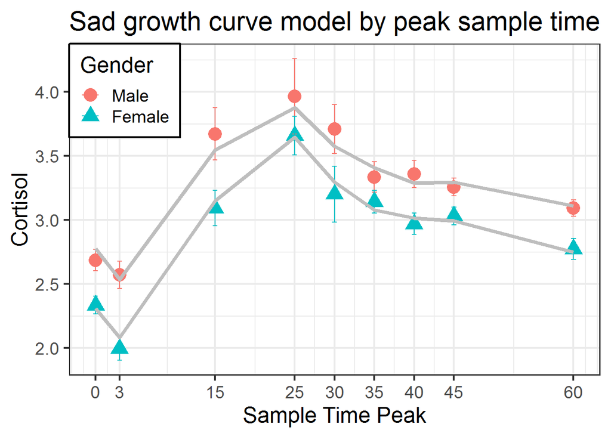

```r
timeticks <- c(0, 3, 15, 25, 30, 35, 40, 45, 60)

cp_long$Sex <- cp_long$gender
cp_long$Sex <- as.factor(cp_long$Sex)
levels(cp_long$Sex) <- c('Male','Female')

ggplot(cp_long, aes(samplepeaknamenum, cortvalue, color=Sex, shape=Sex)) +
stat_summary(fun.y=mean, geom="point", size=5) +
stat_summary(fun.data=mean_se, geom="errorbar",
linetype="solid", width=0.6) +
stat_summary(aes(y=fitted(sad)), fun.y=mean, geom="line", lwd=1.5, col="gray") +
scale_shape_manual(values=c(16, 17)) +
labs(x="Sample Time Peak", y="Cortisol",
color="Gender", shape="Gender") +
theme_bw(base_size=18) +
theme(legend.justification=c(0,1), legend.position=c(0,1),
legend.background=
element_rect(fill="white", color="black")) + scale_x_continuous(breaks=timeticks) + ggtitle("Sad growth curve model by peak sample time")
```

```r
rm(timeticks)
```

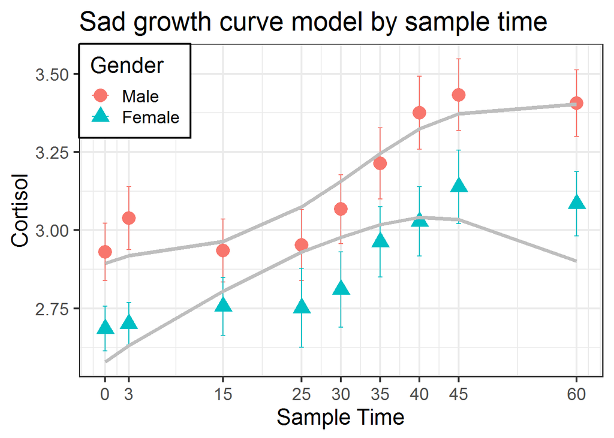

```r
timeticks <- c(0, 3, 15, 25, 30, 35, 40, 45, 60)

cp_long$Sex <- cp_long$gender
cp_long$Sex <- as.factor(cp_long$Sex)
levels(cp_long$Sex) <- c('Male','Female')

ggplot(cp_long, aes(sampletime, cortvalue, color=Sex, shape=Sex)) +
stat_summary(fun.y=mean, geom="point", size=5) +
stat_summary(fun.data=mean_se, geom="errorbar",
linetype="solid", width=0.6) +
stat_summary(aes(y=fitted(sad)), fun.y=mean, geom="line", lwd=1.5, col="gray") +
scale_shape_manual(values=c(16, 17)) +
labs(x="Sample Time", y="Cortisol",
color="Gender", shape="Gender") +
theme_bw(base_size=18) +
theme(legend.justification=c(0,1), legend.position=c(0,1),
legend.background=
element_rect(fill="white", color="black")) + scale_x_continuous(breaks=timeticks) + ggtitle("Sad growth curve model by sample time")
```

```r
rm(timeticks)
```

# Additional analysis

## AIC

```r
AIC(base)
```

```
## [1] 4546.715
```

```r
AIC(sad)
```

```
## [1] 4546.753
```

## BIC

```r
BIC(base)
```

```
## [1] 4606.308
```

```r
BIC(sad)
```

```
## [1] 4611.764
```

## R-squared

```r
r.squaredGLMM(base)
```

```
##            R2m       R2c
## [1,] 0.1235943 0.2889896
```

```r
r.squaredGLMM(sad)
```

```
##            R2m       R2c
## [1,] 0.1257154 0.2917865
```

## Writing out the new cp_long

```r
#write.csv(cp_long, file="/Users/Julianna/Desktop/data/cp_long_aim2a.csv")
#write.csv(cp_long, file="C:/Users/jrcala/Documents/My Research/RStudio/cp_long_aim2a.csv")
```